In what follows, you can find the analyses for the results reported in the paper. To see the underlying code, click on the button “code”.

# Setup

## Packages

Let’s first load the packages we require for our analyses. Note that some need to be installed manually from github.

```r
# install github packages
# devtools::install_github("tdienlin/td@v0.0.2.6")  # uncomment to install
# devtools::install_github("yrosseel/lavaan")
# remotes::install_github("stan-dev/cmdstanr")

# define packages
packages <-
  c(
    "brms",
    "cowplot",
    "devtools",
    "english",
    "faoutlier",
    "GGally",
    "kableExtra",
    "knitr",
    "lavaan",
    "magrittr",
    "marginaleffects",
    "MVN",
    "pwr",
    "quanteda",
    "semTools",
    "tidyverse",
    "cmdstanr",
    "td"
    )

# load packages
lapply(
  packages
  # , install.packages
  , library
  , character.only = TRUE
  , quietly = TRUE
  )

# If not wanting to compute all transformations etc., simply load workspace
# load("data/workspace.RData")
```

## Custom Functions

We now build some custom functions required for the analyses. Note that here you can find the syntax for the main analyses wrapped in helper functions, which we will then call below.

```r
# define function to silence result output
# needed for brms
hush <-
  function(
    code
    ){
    sink("/dev/null") # use /dev/null in UNIX
    tmp = code
    sink()
    return(tmp)
    }

# plot distributions of items
plot_dist <-
  function(
    item,
    n_rows = 1
    ) {
    ggplot(
      gather(
        select(
          d,
          starts_with(
            item
            )
          )
        ),
      mapping = aes(
        x = value
        )
      ) +
      geom_bar() +
      facet_wrap(
        ~key,
        nrow = n_rows
        ) +
      theme_bw()
  }

get_desc <-
  function(
    item,
    name
  ) {
    desc <-
      select(
        d,
        starts_with(
          item
          )
        ) %>%
      apply(
        1,
        mean,
        na.rm = TRUE
        ) %>%
      as.data.frame() %>%
      summarise(
        m = mean(., na.rm = TRUE),
        sd = sd(., na.rm = TRUE)
        )
    assign(
      paste0(
        "des_",
        name
      ),
      desc,
      envir = .GlobalEnv
    )
  }

# Function to display diagnostics of fitted hurdle models
model_diagnostics <-
  function(
    model
  ){
  plot_grid(
    pp_check(
      model,
      type = "dens_overlay",
      nsamples = 100
    ),
    pp_check(
      model,
      type = "loo_pit_qq",
      nsamples = 100
    ),
    pp_check(
      model,
      type = "stat",
      stat = "median",
      nsamples = 100
    ),
    pp_check(
      model,
      type = "stat",
      stat = "mean",
      nsamples = 100
    ),
    labels = c("Density overlay", "LOO-PIT QQ", "Predicted medians", "Predicted means"),
    ncol = 2,
    label_size = 8,
    hjust = 0,
    vjust = 0,
    label_x = 0,
    label_y = 0.93
    )
  }

# wrapper function that runs relevant analyses for hurdle models
run_hurdles <-
  function(
    object,
    name,
    outcome,
    predictor,
    x_lab,
    y_lab,
    plot = FALSE,
    ...
    ){

    # define define general model
    formula_mdl <-
      formula(
        paste0(
          outcome,
          " ~ 1 + age + male + edu +",
          predictor
        )
    )

    # define hurdle model
    formula_hrdl <-
      formula(
        paste0(
          "hu ~ 1 + age + male + edu +",
          predictor
        )
    )

    # fit model
    fit <-
      hush(
        brms::brm(
          bf(
            formula_mdl,
            formula_hrdl
            ),
          data = object,
          family = hurdle_gamma(),
          silent = TRUE,
          refresh = 0,
          iter = 1000,
          backend = "rstan"
          )
      )

    # export fit
    assign(
      paste0(
        "fit_",
        name),
      fit,
      envir = .GlobalEnv
    )

    # plot model
    if(
      isTRUE(plot
             )) {
      plot(fit, ask = FALSE)
  }

    # run diagnostics
    fit_diagnostics <-
      model_diagnostics(fit)
    plot(fit_diagnostics)

    # print summary
    fit_summary <-
      summary(fit)
    print(fit_summary)

    # calculate slopes
    slopes <-
      cbind(
        Outcome = outcome,
        avg_slopes(fit)
      )

    # print slopes
    cat("\nResults of marginal effects:\n")
    print(slopes)

    # export as object to environment
    assign(
      paste0(
        "slopes_",
        name
        ),
      slopes,
      envir = .GlobalEnv
    )

    # make figure
    fig_res <-
      conditional_effects(
        fit
        , ask = FALSE
      )

    # make figure
    fig <-
      plot(
        fig_res,
        plot = FALSE
      )[[predictor]] +
      labs(
        x = x_lab,
        y = y_lab
        )

    # plot figure
    print(fig)

    # export as object to environment
    assign(
      paste0(
        "fig_",
        name
      ),
      fig,
      envir = .GlobalEnv
    )
}
```

## Data-Wrangling

Let’s next tidy up and prepare the data, so we can analyze them.

```r
# load data
# please note that in a prior step several different data sets were merged using information such as case_taken or IP-addresses. To guarantee the privacy of the participants, these data were deleted after merging.
d_raw <- read_csv("data/data_raw.csv")

# recode variables
d <-
  d_raw %>%
  dplyr::rename(
    "male" = "SD01",
    "age" = "SD02_01",
    "state" = "SD03",
    "edu_fac" = "SD04",
    "TR02_01" = "TR01_01",
    "TR02_02" = "TR01_05",
    "TR02_03" = "TR01_09",
    "TR01_01" = "TR01_02",
    "TR01_02" = "TR01_03",
    "TR01_03" = "TR01_04",
    "TR01_04" = "TR01_06",
    "TR01_05" = "TR01_07",
    "TR01_06" = "TR01_08",
    "TR01_07" = "TR01_10",
    "TR01_08" = "TR01_11",
    "TR01_09" = "TR01_12"
    ) %>%
  mutate(

    #general
    version = factor(
      VE01_01,
      labels = c(
        "Control",
        "Like",
        "Like & dislike"
        )
      ),
    version_lkdslk = factor(
      version,
      levels = c(
        "Like & dislike",
        "Like",
        "Control"
        )
      ),
    version_no = recode(
      version,
      "Control" = 1,
      "Like" = 2,
      "Like & dislike" = 3
      ),
    male = replace_na(
      male,
      "[3]") %>%
      dplyr::recode(
        "männlich [1]" = 1,
        "weiblich [2]" = 0
        ),
    age_grp = cut(
      age,
      breaks = c(0, 29, 39, 49, 59, 100),
      labels = c("<30", "30-39", "40-49", "50-59", ">59")
      ),

    # contrasts
    like = recode(
      version,
      "Control" = 0,
      "Like" = 1,
      "Like & dislike" = 0
      ),
    likedislike = recode(
      version,
      "Control" = 0,
      "Like" = 0,
      "Like & dislike" = 1
      ),
    control = recode(
      version,
      "Control" = 1,
      "Like" = 0,
      "Like & dislike" = 0
      ),

    # recode
    edu = recode(
      edu_fac,
      "Hauptschulabschluss/Volksschulabschluss" = 1,
      "Noch Schüler" = 1,
      "Realschulabschluss (Mittlere Reife)" = 1,
      "Abschluss Polytechnische Oberschule 10. Klasse (vor 1965: 8. Klasse)" = 1,
      "Anderer Schulabschluss:" = 1,
      "Fachhochschulreife (Abschluss einer Fachoberschule)" = 2,
      "Abitur, allgemeine oder fachgebundene Hochschulreife (Gymnasium bzw. EOS)" = 2,
                 "Hochschulabschluss" = 3),
    PC01_03 = 8 - PC01_03,
    SE01_05 = 8 - SE01_05,
    SE01_06 = 8 - SE01_06,

    # behavioral data
    words = replace_na(
      words,
      0
      ),
    self_dis = words + (reactions * 2),
    time_read_MIN = time_read / 60,
    time_sum_min_t2 = TIME_SUM_t2 / 60,

    # take logarithm
    words_log = log1p(words),
    self_dis_log = log1p(self_dis)
  )

# variable labels
var_names <- c(
  "Privacy concerns",
  "Gratifications general",
  "Gratifications specific",
  "Privacy deliberation",
  "Self-efficacy",
  "Trust general",
  "Trust specific",
  "Words log"
  )

var_names_breaks <- c(
  "Privacy\nconcerns",
  "Gratifications\ngeneral",
  "Gratifications\nspecific",
  "Privacy\ndeliberation",
  "Self-\nefficacy",
  "Trust\ngeneral",
  "Trust\nspecific",
  "Words (log)"
  )

# Extract sample characteristics and descriptives.
# sample descriptives t1
n_t1 <- nrow(d)
age_t1_m <- mean(d$age, na.rm = TRUE)
male_t1_m <- mean(d$male, na.rm = TRUE)
college_t1_m <- table(d$edu)[3] / n_t1

# sample descriptives t2
# participants
n_t2 <-
  filter(
    d,
    !is.na(
      id_survey_t2
      )
    ) %>%
  nrow()

# age
age_t2_m <-
  filter(
    d,
    !is.na(
      id_survey_t2
      )
    ) %>%
  select(
    age
    ) %>%
  mean()

# gender
male_t2_m <-
  filter(
    d,
    !is.na(
      id_survey_t2
      )
    ) %>%
  select(
    male
    ) %>%
  mean(
    na.rm = TRUE
    )

# education
college_t2_m <-
  filter(
    d,
    !is.na(
      id_survey_t2
      )
    ) %>%
  select(
    edu
    ) %>%
  table() %>%
  .[3] / n_t2

# descriptives users
n_users <-
  filter(
    d,
    !is.na(
      post_count
      )
    ) %>%
  nrow()

# characteristics of posts
n_comments <-
  sum(
    d$post_count,
    na.rm = TRUE
    )

n_words <-
  sum(
    d$words,
    na.rm = TRUE
    )

n_time <-
  sum(
    d$time_read_MIN,
    na.rm = TRUE
    )

n_posts <-
  sum(
    d$post_count,
    na.rm = TRUE
    )

# filter unmatched cases, use only completes
d <-
  filter(
    d,
    !is.na(
      post_count
      ) & !is.na(
        id_survey_t2
        )
    )

n_matched <- nrow(d)

# save data file with all participants to compare results
d_all <- d
```

# Filter Participants

I filtered participants who answered the questionnaire in less than three minutes, which I considered to be unreasonably fast.

```r
# filter speeders
time_crit <- 3 # minimum time on survey

# count number of speeders
n_speeding <-
  nrow(
    filter(
      d,
      time_sum_min_t2 < time_crit
      )
    )

# Deletion of fast respondents
d <-
  filter(
    d,
    time_sum_min_t2 >= time_crit
    )
```

I inspected the data manually for cases with obvious response patterns. The following cases show extreme response patterns (alongside fast response times), and were hence removed.

```r
# identify response patterns
resp_pattern <- c(
  "ANIEVLK9F2SW",
  "BN4MAOWZO7W2"  # clear response pattern
  )

n_resp_pattern <-
  length(
    resp_pattern
    )

d %>%
  filter(
    case_token %in% resp_pattern
    ) %>%
  select(
    case_token,
    GR01_01:SE01_06,
    topics_entered:reactions,
    -SO01_01,
    TIME_SUM_t1,
    TIME_SUM_t2
    ) %>%
  kable() %>%
  kable_styling("striped") %>%
  scroll_box(width = "100%")
```

| case_token | GR01_01 | GR01_02 | GR01_03 | GR01_04 | GR01_05 | GR01_06 | GR01_07 | GR01_08 | GR01_09 | GR01_10 | GR01_11 | GR01_12 | GR01_13 | GR01_14 | GR01_15 | GR02_01 | GR02_02 | GR02_03 | GR02_04 | GR02_05 | PC01_01 | PC01_02 | PC01_03 | PC01_04 | PC01_05 | PC01_06 | PC01_07 | TR02_01 | TR01_01 | … |
| --- | --- | --- | --- | --- | --- | --- | --- | --- | --- | --- | --- | --- | --- | --- | --- | --- | --- | --- | --- | --- | --- | --- | --- | --- | --- | --- | --- | --- | --- | --- |
| BN4MAOWZO7W2 | 7 | 7 | 7 | 7 | 7 | 7 | 7 | 7 | 7 | 7 | 7 | 7 | 7 | 7 | 7 | 7 | 7 | 7 | 7 | 7 | 7 | 7 | 1 | 7 | 7 | 7 | 7 | 4 | 1 | … |
| ANIEVLK9F2SW | 1 | 1 | 1 | 1 | 1 | 1 | 1 | 1 | 1 | 1 | 1 | 1 | 1 | 1 | 1 | 1 | 1 | 1 | 1 | 1 | 1 | 1 | 1 | 1 | 1 | 1 | 1 | 1 | 1 | … |

```r
d %<>%
  filter(
    !case_token %in% resp_pattern
    )

# sample descriptives final data set
n_final <- nrow(d)
age_final_m <- mean(d$age)
male_final_m <- mean(d$male, na.rm = TRUE)
college_final_m <- table(d$edu)[[3]] / n_final
```

# Measures

Let’s next inspect all measures. I list all items, their distributions and CFAs.

## Privacy concerns

### Items

Using the participation platform I had …

1. … concerns about what happens to my data.
2. … concerns about disclosing information about myself.
3. … no concerns. (reversed)
4. … concerns that others could discover my real identity (i.e. my last and first name).
5. … concerns that information about myself could fall into wrong hands.
6. … concerns that others could discover what my political views are.
7. … concerns about my privacy.

### Distributions

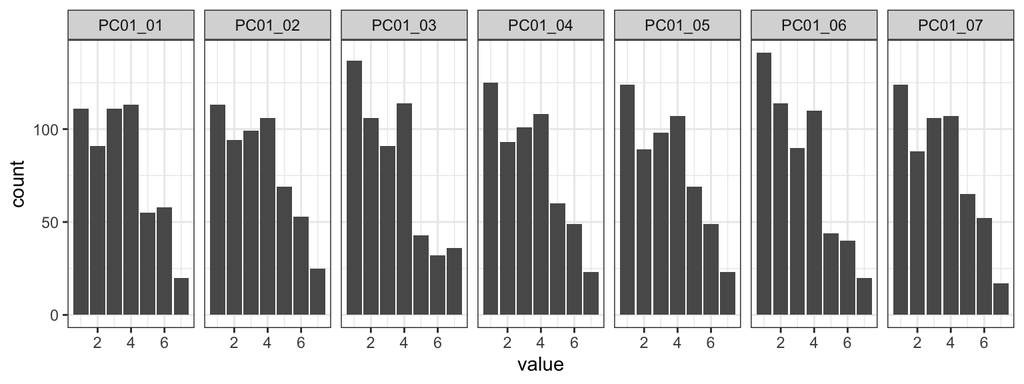

```r
# plot distribution
plot_dist(
  item = "PC01"
)
```

```r
# extract results
get_desc(
  item = "PC01",
  name = "pricon"
)
```

### CFA

```r
name <- "pricon"
model <- "
pri_con =~ PC01_01 + PC01_02 + PC01_03 + PC01_04 + PC01_05 + PC01_06 + PC01_07
"
fit <-
  lavaan::sem(
    model = model,
    data = d,
    estimator = "MLR",
    missing = "ML"
    )
```

Model fit:

```r
facval <-
  fit_tab(
    fit,
    # reliability = TRUE,
    # scaled = TRUE
    ) %T>%
  print()
```

```
   chisq       df   pvalue      cfi      tli    rmsea     srmr
31.89818 14.00000  0.00414  0.99542  0.99312  0.04782  0.01045
```

Factor loadings:

```r
inspect(
  fit,
  what = "std") %$%
    lambda
```

```
        pri_cn
PC01_01  0.931
PC01_02  0.901
PC01_03  0.547
PC01_04  0.890
PC01_05  0.908
PC01_06  0.795
PC01_07  0.928
```

Shows that PC01_03 doesn’t load well. As it’s an inverted item that’s not surprising. Also from a theoretic perspective it’s suboptimal, because it doesn’t explicitly focus on privacy, but just concerns in general. Will be deleted.

### CFA 2

```r
model <- "
pri_con =~ PC01_01 + PC01_02 + PC01_04 + PC01_05 + PC01_06 + PC01_07
"
fit <-
  lavaan::sem(
    model = model,
    data = d,
    estimator = "MLR",
    missing = "ML"
    )
```

Model fit:

```r
facval <-
  fit_tab(
    fit,
    # reliability = TRUE,
    # scaled = TRUE
    ) %T>%
  print()
```

```
   chisq       df   pvalue      cfi      tli    rmsea     srmr
25.83639  9.00000  0.00217  0.99547  0.99244  0.05785  0.00963
```

```r
assign(
  paste0(
    name,
    "_facval"
    ),
  facval
  )
```

Factor loadings:

```r
inspect(
  fit,
  what = "std"
  ) %$%
  lambda
```

```
        pri_cn
PC01_01  0.931
PC01_02  0.901
PC01_04  0.891
PC01_05  0.909
PC01_06  0.796
PC01_07  0.926
```

Updated version shows good fit.

## Gratifications general

### Items

Using the participation platform …

1. … had many benefits for me.
2. … has paid off for me.
3. … was worthwhile.
4. … was fun.
5. … has brought me further regarding content.

### Distributions

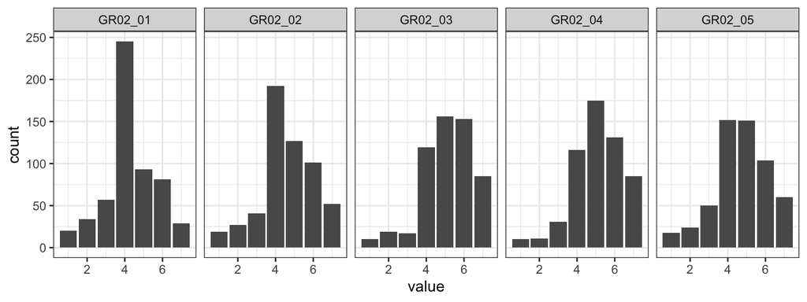

```r
plot_dist(
  item = "GR02"
)
```

```r
get_desc(
  item = "GR02",
  name = "gratsgen"
)
```

### CFA

```r
name <- "gratsgen"
model <- "
  grats_gen =~ GR02_01 + GR02_02 + GR02_03 + GR02_04 + GR02_05
"
fit <-
  lavaan::sem(
    model = model,
    data = d,
    estimator = "MLR",
    missing = "ML"
    )
```

Model fit:

```r
facval <-
  fit_tab(
    fit,
    # reliability = TRUE,
    # scaled = TRUE
    ) %T>%
  print()
```

```
   chisq       df   pvalue      cfi      tli    rmsea     srmr
5.31e+01 5.00e+00 3.22e-10 9.79e-01 9.58e-01 1.31e-01 1.93e-02
```

```r
assign(
  paste0(
    name,
    "_facval"
    ),
  facval
  )
```

Factor loadings:

```r
inspect(
  fit,
  what = "std"
  ) %$%
  lambda
```

```
        grts_g
GR02_01  0.853
GR02_02  0.908
GR02_03  0.851
GR02_04  0.837
GR02_05  0.848
```

Model fit was good.

## Gratifications specific

### Items

Using the participation platform it has been possible for me …

*Information*

1. … to learn things I would not otherwise have noticed.
2. … to hear the opinion of others.
3. … to learn how other people tick.

*Relevance*

4. … to react to a subject that is very dear to me.
5. … to react to a subject that is important to me.
6. … to react to a subject that I am affected by.

*Political participation*

7. … to engage politically.
8. … to discuss political issues.
9. … to pursue my political interest.

*Idealism*

10. … to try to improve society.
11. … to advocate to something meaningful.
12. … to serve a good purpose.

*Extrinsic benefits*

13. … to do the responsible persons a favor.
14. … to soothe my guilty consciences.
15. … to fulfil my civic duty.

### Distributions

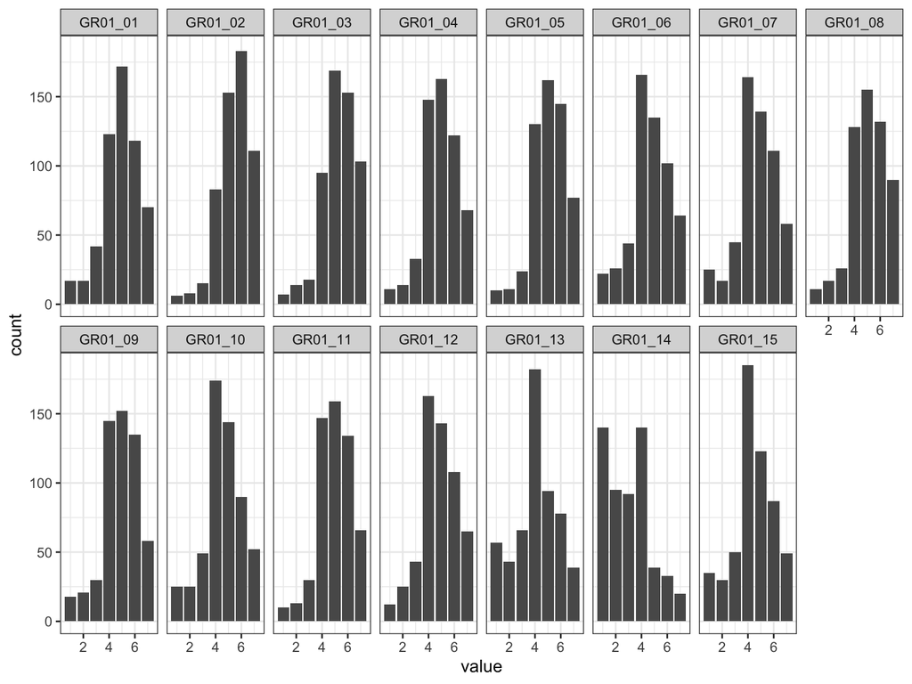

```r
plot_dist(
  item = "GR01",
  n_rows = 2
)
```

```r
get_desc(
  item = "GR01",
  name = "gratsspec"
)
```

### CFA

```r
name <- "gratsspec"
model <- "
  grats_inf =~ GR01_01 + GR01_02 + GR01_03
  grats_rel =~ GR01_04 + GR01_05 + GR01_06
  grats_par =~ GR01_07 + GR01_08 + GR01_09
  grats_ide =~ GR01_10 + GR01_11 + GR01_12
  grats_ext =~ GR01_13 + GR01_14 + GR01_15
  grats_spec =~ grats_inf + grats_rel + grats_par + grats_ide + grats_ext
"
fit <- lavaan::sem(
  model = model,
  data = d,
  estimator = "MLR",
  missing = "ML"
  )
```

Model fit:

```r
facval <-
  fit_tab(
    fit,
    # reliability = TRUE,
    # scaled = TRUE
    ) %T>%
  print()
```

```
   chisq       df   pvalue      cfi      tli    rmsea     srmr
441.3886  85.0000   0.0000   0.9340   0.9184   0.0866   0.0527
```

```r
assign(
  paste0(
    name,
    "_facval"
    ),
  facval
  )
```

Factor loadings:

```r
inspect(
  fit,
  what = "std"
  ) %$%
  lambda
```

```
        grts_n grts_r grts_p grts_d grts_x grts_s
GR01_01  0.688  0.000  0.000  0.000  0.000      0
GR01_02  0.819  0.000  0.000  0.000  0.000      0
GR01_03  0.851  0.000  0.000  0.000  0.000      0
GR01_04  0.000  0.891  0.000  0.000  0.000      0
GR01_05  0.000  0.852  0.000  0.000  0.000      0
GR01_06  0.000  0.704  0.000  0.000  0.000      0
GR01_07  0.000  0.000  0.826  0.000  0.000      0
GR01_08  0.000  0.000  0.811  0.000  0.000      0
GR01_09  0.000  0.000  0.816  0.000  0.000      0
GR01_10  0.000  0.000  0.000  0.796  0.000      0
GR01_11  0.000  0.000  0.000  0.882  0.000      0
GR01_12  0.000  0.000  0.000  0.762  0.000      0
GR01_13  0.000  0.000  0.000  0.000  0.519      0
GR01_14  0.000  0.000  0.000  0.000  0.513      0
GR01_15  0.000  0.000  0.000  0.000  0.848      0
```

Model fit was okay.

## Privacy deliberation

### Items

Using the participation platform …

1. … I have considered whether I could be disadvantaged by writing a comment.
2. … I have considered whether I could be advantaged by writing a comment.
3. … I have weighed up the advantages and disadvantages of writing a comment.
4. … I have thought about consequences of a possible comment.
5. … I have considered whether I should write a comment or not.

### Distributions

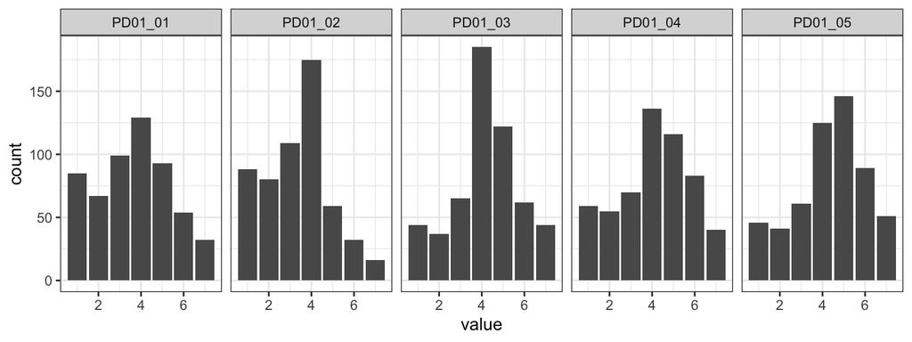

```r
plot_dist(
  item = "PD01"
)
```

```r
get_desc(
  item = "PD01",
  name = "pridel"
)
```

### CFA

```r
name <- "pridel"
model <- "
  pri_delib =~ PD01_01 + PD01_02 + PD01_03 + PD01_04 + PD01_05
"
fit <- lavaan::sem(
  model = model,
  data = d,
  estimator = "MLR",
  missing = "ML"
  )
```

Model fit:

```r
facval <-
  fit_tab(
    fit,
    # reliability = TRUE,
    # scaled = TRUE
    ) %T>%
  print()
```

```
   chisq       df   pvalue      cfi      tli    rmsea     srmr
2.74e+01 5.00e+00 4.71e-05 9.79e-01 9.58e-01 8.96e-02 2.35e-02
```

```r
assign(
  paste0(
    name,
    "_facval"),
  facval
  )
```

Factor loadings:

```r
inspect(
  fit,
  what = "std"
  ) %$%
  lambda
```

```
        pr_dlb
PD01_01  0.849
PD01_02  0.653
PD01_03  0.691
PD01_04  0.752
PD01_05  0.656
```

## Trust general

### Items

1. The other users seemed trustworthy.
2. The operators of the participation platform seemed trustworthy.
3. The website seemed trustworthy.

### Distributions

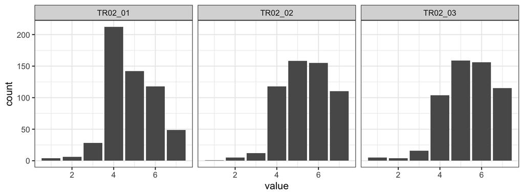

```r
plot_dist(
  item = "TR02"
)
```

```r
get_desc(
  item = "TR02",
  name = "trustgen"
)
```

### CFA

Note that I constrained two loadings to be able to report model fit. I used operators and website, as these are theoretically closer.

```r
name <- "trustgen"
model <- "
trust =~ TR02_01 + a*TR02_02 + a*TR02_03
"
fit <-
  lavaan::sem(
    model = model,
    data = d,
    estimator = "MLR",
    missing = "ML"
    )
```

Model fit:

```r
facval <-
  fit_tab(
    fit,
    # reliability = TRUE,
    # scaled = TRUE
    ) %T>%
  print()
```

```
 chisq     df pvalue    cfi    tli  rmsea   srmr
1.8597 1.0000 0.1727 0.9991 0.9972 0.0392 0.0125
```

```r
assign(
  paste0(
    name,
    "_facval"
    ),
  facval
  )
```

Factor loadings:

```r
inspect(
  fit,
  what = "std"
  ) %$%
  lambda
```

```
        trust
TR02_01 0.660
TR02_02 0.923
TR02_03 0.898
```

Note that I constrained Items 5 and Item 9 to be equal. Explanation: First, they are theoretically related. Second, not constraining would yield to just-identified model, for which model fit cannot be interpreted meaningfully.

## Trust specific

### Items

*Community*

1. The comments of other users were useful.
2. The other users had good intentions.
3. I could rely on the statements of other users.

*Provider*

4. The operators of the participation platform have done a good job.
5. It was important to the operators that the users are satisfied with the participation platform.
6. I could rely on the statements of the operators of the participation platform.

*Information System*

7. The website worked well.
8. I had the impression that my data was necessary for the use of the website.
9. I found the website useful.

### Distributions

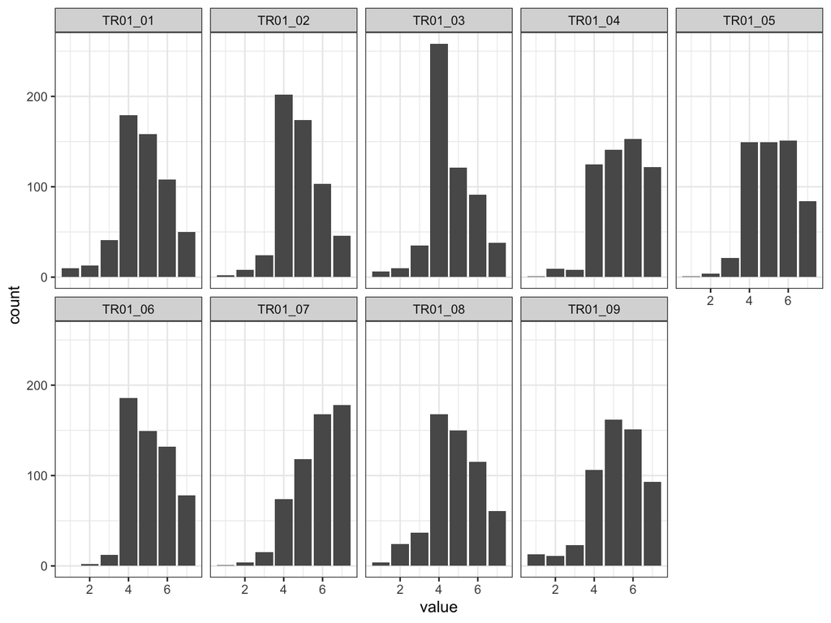

```r
plot_dist(
  item = "TR01",
  n_rows = 2
)
```

```r
get_desc(
  item = "TR01",
  name = "trustspec"
)
```

### CFA

```r
name <- "trustspec"
model <- "
  trust_community =~ TR01_01 + TR01_02 + TR01_03
  trust_provider =~ TR01_04 + TR01_05 + TR01_06
  trust_system =~ TR01_07 + TR01_08 + TR01_09

  trust_spec =~ trust_community + trust_provider + trust_system
"
fit <- lavaan::sem(
  model = model,
  data = d,
  estimator = "MLR",
  missing = "ML"
  )
```

Model fit:

```r
facval <-
  fit_tab(
    fit,
    # reliability = TRUE,
    # scaled = TRUE
    ) %T>%
  print()
```

```
   chisq       df   pvalue      cfi      tli    rmsea     srmr
153.1169  24.0000   0.0000   0.9592   0.9388   0.0981   0.0351
```

```r
assign(
  paste0(
    name,
    "_facval"
    ),
  facval
  )
```

Factor loadings:

```r
inspect(
  fit,
  what = "std") %$%
  lambda
```

```
        trst_c trst_p trst_sy trst_sp
TR01_01  0.814  0.000   0.000       0
TR01_02  0.765  0.000   0.000       0
TR01_03  0.822  0.000   0.000       0
TR01_04  0.000  0.884   0.000       0
TR01_05  0.000  0.779   0.000       0
TR01_06  0.000  0.793   0.000       0
TR01_07  0.000  0.000   0.690       0
TR01_08  0.000  0.000   0.662       0
TR01_09  0.000  0.000   0.817       0
```

Model fit was good (there’s a Highwood case on level 1, which is not too problematic in this case.)

## Self-efficacy

### Items

1. In principle, I felt able to write a comment.
2. I felt technically competent enough to write a comment.
3. In terms of the topic, I felt competent enough to express my opinion.
4. I found it easy to express my opinion regarding the topic.
5. I found it complicated to write a comment. (reversed)
6. I was overburdened to write a comment. (reversed)

### Distributions

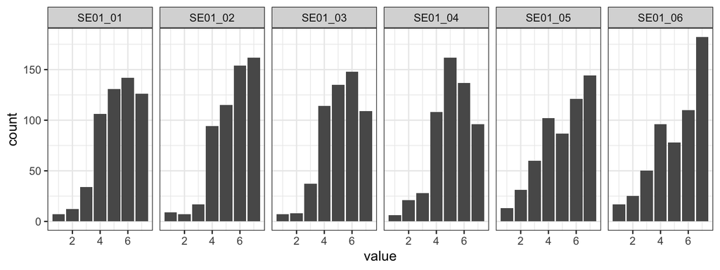

```r
plot_dist(
  item = "SE01"
)
```

```r
get_desc(
  item = "SE01",
  name = "selfeff"
)
```

### CFA

```r
name <- "self-eff"
model <- "
  self_eff =~ SE01_01 + SE01_02 + SE01_03 + SE01_04 + SE01_05 + SE01_06
"
fit <-
  lavaan::sem(
    model = model,
    data = d,
    estimator = "MLR",
    missing = "ML"
    )
```

Model fit:

```r
facval <-
  fit_tab(
    fit,
    # reliability = TRUE,
    # scaled = TRUE
    ) %T>%
  print()
```

```
   chisq       df   pvalue      cfi      tli    rmsea     srmr
207.8939   9.0000   0.0000   0.8733   0.7889   0.1990   0.0671
```

```r
assign(
  paste0(
    name,
    "_facval"
    ),
  facval
  )
```

Factor loadings:

```r
inspect(
  fit,
  what = "std") %$%
  lambda
```

```
        slf_ff
SE01_01  0.842
SE01_02  0.689
SE01_03  0.764
SE01_04  0.801
SE01_05  0.528
SE01_06  0.633
```

Shows significant misfit. I will delete inverted items, while allowing covariations between Items 1 and 2 (tech-oriented) and Items 3 and 4 (topic-oriented).

### CFA 2

```r
name <- "selfeff"
model <- "
  self_eff_pos =~ SE01_01 + SE01_02 + SE01_03 + SE01_04
  SE01_01 ~~ x*SE01_02
  SE01_03 ~~ x*SE01_04
"
fit <-
  lavaan::sem(
    model = model,
    data = d,
    estimator = "MLR",
    missing = "ML"
    )
```

Model fit:

```r
facval <-
  fit_tab(
    fit,
    # reliability = TRUE,
    # scaled = TRUE
    ) %T>%
  print()
```

```
   chisq       df   pvalue      cfi      tli    rmsea     srmr
10.53143  1.00000  0.00117  0.99088  0.94526  0.13070  0.01360
```

```r
assign(
  paste0(
    name,
    "_facval"
    ),
  facval
  )
```

Factor loadings:

```r
inspect(
  fit,
  what = "std") %$%
  lambda
```

```
        slf_f_
SE01_01  0.828
SE01_02  0.675
SE01_03  0.779
SE01_04  0.787
```

Adapted version shows better and adequate fit.

## Communication

### Density plot

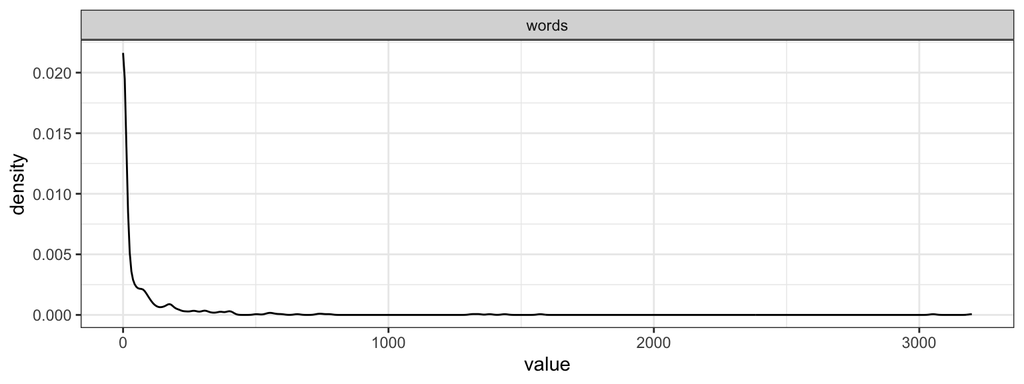

```r
ggplot(
  gather(
    select(
      d,
      words
      )
    ),
  mapping = aes(
    x = value
    )
  ) +
  geom_density() +
  facet_wrap(
    ~key,
    nrow = 1
    ) +
  theme_bw()
```

We can see that Communication is severely skewed. Let’s calculate how many participants actually commented.

```r
no_words_perc <-
  d %>%
  select(words) %>%
  table() %>%
  prop.table() %>%
  .[1] %>%
  unlist()

words_m <-
  mean(
    d$words,
    na.rm = TRUE
    )
```

Will hence be log-scaled for SEMs.

## Communication Logged

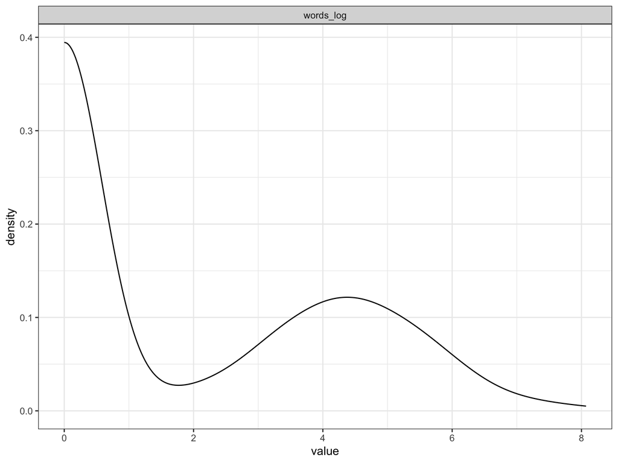

```r
ggplot(
  gather(
    select(
      d,
      words_log
      )
    ),
  mapping = aes(
    x = value
    )
  ) +
  geom_density() +
  facet_wrap(
    ~key,
    nrow = 1
    ) +
  theme_bw()
```

## Baseline model

In what follows, please find the results of all variables combined in one model. This model will be used to extract factor scores.

```r
model_baseline <- "
  pri_con =~ PC01_01 + PC01_02 + PC01_04 + PC01_05 + PC01_06 + PC01_07
  grats_gen =~ GR02_01 + GR02_02 + GR02_03 + GR02_04 + GR02_05
  grats_inf =~ GR01_01 + GR01_02 + GR01_03
  grats_rel =~ GR01_04 + GR01_05 + GR01_06
  grats_par =~ GR01_07 + GR01_08 + GR01_09
  grats_ide =~ GR01_10 + GR01_11 + GR01_12
  grats_ext =~ GR01_13 + GR01_14 + GR01_15
  grats_spec =~ grats_inf + grats_rel + grats_par + grats_ide + grats_ext
  pri_delib =~ PD01_01 + PD01_02 + PD01_03 + PD01_04 + PD01_05
  trust_gen =~ TR02_01 + TR02_02 + TR02_03
  trust_community =~ TR01_01 + TR01_02 + TR01_03
  trust_provider =~ TR01_04 + TR01_05 + TR01_06
  trust_system =~ TR01_07 + TR01_08 + TR01_09
  trust_spec =~ trust_community + trust_provider + trust_system
  self_eff =~ SE01_01 + SE01_02 + SE01_03 + SE01_04
    SE01_01 ~~ x*SE01_02
    SE01_03 ~~ x*SE01_04
  Words_log =~ words_log

  Words_log ~~ a1*pri_con + b1*grats_gen + c1*pri_delib + d1*self_eff + e1*trust_spec + f1*trust_gen + g1*grats_spec
"

fit_baseline <-
  lavaan::sem(
    model_baseline,
    data = d,
    missing = "ML"
    )

summary(
  fit_baseline,
  standardized = TRUE,
  fit.measures = TRUE
  )
```

```
lavaan 0.7-2 ended normally after 169 iterations

  Estimator                                         ML
  Optimization method                           NLMINB
  Number of model parameters                       181
  Number of equality constraints                     1

  Number of observations                           559
  Number of missing patterns                         3

Model Test User Model:

  Test statistic                              3210.778
  Degrees of freedom                              1044
  P-value (Chi-square)                           0.000

Model Test Baseline Model:

  Test statistic                             22544.020
  Degrees of freedom                              1128
  P-value                                        0.000

User Model versus Baseline Model:

  Comparative Fit Index (CFI)                    0.899
  Tucker-Lewis Index (TLI)                       0.891

  Robust Comparative Fit Index (CFI)             0.899
  Robust Tucker-Lewis Index (TLI)                0.891

Loglikelihood and Information Criteria:

  Loglikelihood user model (H0)             -37699.172
  Loglikelihood unrestricted model (H1)     -36093.783

  Akaike (AIC)                               75758.344
  Bayesian (BIC)                             76537.051
  Sample-size adjusted Bayesian (SABIC)      75965.644

Root Mean Square Error of Approximation:
```

[output cut: 258 more lines]

```
    grats_gen         1.273    0.105   12.120    0.000    1.000    1.000
   .grats_inf         0.277    0.038    7.350    0.000    0.290    0.290
   .grats_rel         0.207    0.033    6.248    0.000    0.150    0.150
   .grats_par         0.129    0.031    4.095    0.000    0.091    0.091
   .grats_ide         0.159    0.031    5.120    0.000    0.120    0.120
   .grats_ext         0.282    0.054    5.183    0.000    0.390    0.390
    grats_spec        0.680    0.092    7.415    0.000    1.000    1.000
    pri_delib         2.231    0.185   12.033    0.000    1.000    1.000
    trust_gen         0.663    0.071    9.319    0.000    1.000    1.000
   .trust_communty    0.286    0.036    7.946    0.000    0.272    0.272
   .trust_provider    0.050    0.019    2.591    0.010    0.046    0.046
   .trust_system     -0.043    0.016   -2.739    0.006   -0.065   -0.065
    trust_spec        0.763    0.082    9.256    0.000    1.000    1.000
    self_eff          1.288    0.116   11.135    0.000    1.000    1.000
    Words_log         5.341    0.319   16.718    0.000    1.000    1.000
```

# Descriptive analyses

I first report the factor validity of all variables combined.

```r
# extract model factor scores / predicted values for items & calc means
d_fs <-
  lavPredict(
    fit_baseline,
    type = "ov"
    ) %>%
  as.data.frame() %>%
  mutate(
    version = d$version,
    grats_gen_fs = rowMeans(select(., starts_with("GR02"))),
    grats_spec_fs = rowMeans(select(., starts_with("GR01"))),
    pri_con_fs = rowMeans(select(., starts_with("PC01"))),
    trust_gen_fs = rowMeans(select(., starts_with("TR02"))),
    trust_spec_fs = rowMeans(select(., starts_with("TR01"))),
    pri_del_fs = rowMeans(select(., starts_with("PD01"))),
    self_eff_fs = rowMeans(select(., starts_with("SE01")))) %>%
  select(
    version,
    pri_con_fs,
    grats_gen_fs,
    grats_spec_fs,
    pri_del_fs,
    self_eff_fs,
    trust_gen_fs,
    trust_spec_fs,
    words_log
    )

# combine d with d factor scores
d %<>%
  cbind(
    select(
      d_fs,
      -version,
      -words_log
      )
    )

# rename for plotting
d_fs %<>%
  set_names(
    c(
      "version",
      var_names_breaks
      )
    )

# means of model predicted values
des <-
  rbind(
    des_pricon,
    des_gratsgen,
    des_gratsspec,
    des_pridel,
    des_trustgen,
    des_trustspec,
    des_selfeff
    )

facval_tab <-
  rbind(
    pricon_facval,
    gratsgen_facval,
    gratsspec_facval,
    pridel_facval,
    selfeff_facval,
    trustgen_facval,
    trustspec_facval
    ) %>%
      cbind(des[-c(8), ], .) %>%
      set_rownames(var_names[-c(7)])

facval_tab %>%
  kable() %>%
  kableExtra::kable_styling("striped") %>%
  kableExtra::scroll_box(width = "100%")
```

|  | m | sd | chisq | df | pvalue | cfi | tli | rmsea | srmr |
| --- | --- | --- | --- | --- | --- | --- | --- | --- | --- |
| Privacy concerns | 3.21 | 1.514 | 25.84 | 9 | 0.002 | 0.995 | 0.992 | 0.058 | 0.010 |
| Gratifications general | 4.76 | 1.219 | 53.09 | 5 | 0.000 | 0.979 | 0.958 | 0.131 | 0.019 |
| Gratifications specific | 4.71 | 1.019 | 441.39 | 85 | 0.000 | 0.934 | 0.918 | 0.087 | 0.053 |
| Privacy deliberation | 3.93 | 1.285 | 27.43 | 5 | 0.000 | 0.979 | 0.958 | 0.090 | 0.024 |
| Self-efficacy | 5.21 | 1.039 | 10.53 | 1 | 0.001 | 0.991 | 0.945 | 0.131 | 0.014 |
| Trust general | 5.08 | 0.942 | 1.86 | 1 | 0.173 | 0.999 | 0.997 | 0.039 | 0.012 |
| Words log | 5.25 | 1.118 | 153.12 | 24 | 0.000 | 0.959 | 0.939 | 0.098 | 0.035 |

In what follows, I report zero-order correlations, distributions, and scatterplots of the variables’ factor scores.

```r
# corr_plot <-
#   ggpairs(
#     select(d_fs, -version),
#     upper = list(
#       continuous = cor_plot
#     ),
#     lower = list(
#       continuous = wrap(
#         td::scat_plot,
#         coords = c(1, 7, 0, 7)
#       )
#     )
#   ) +
#   theme_bw()

# print(corr_plot)

# ggsave(
#   "figures/results/cor_plot.png",
#   plot = corr_plot,
#   bg = "white",
#   width = 8,
#   height = 8
# )
```

# Power analyses

In what follows, I report power analyses for our study. Please note that I conduct a rudimentary power-analysis, assuming bivariate correlations. (At the time I was not yet aware of the existence of power analyses for multivariate structural equation models.)

I first estimate the sample size necessary to find small effects in 95% of all cases.

```r
# estimate pwr-samplesize
pwr.r.test(
  r = r_sesoi,
  sig.level = alpha,
  power = power_desired,
  alternative = "greater"
  ) %T>%
  print %$%
  n %>%
  round(0) ->
  n_desired
```

```
     approximate correlation power calculation (arctangh transformation)

              n = 1077
              r = 0.1
      sig.level = 0.05
          power = 0.95
    alternative = greater
```

I then compute the power we have achieved with our final sample size to detect small effects.

```r
# compute pwr-achieved
pwr.r.test(
  n = n_final,
  r = r_sesoi,
  sig.level = alpha,
  alternative = "greater"
  ) %T>%
  print %$%
  power %>%
  round(2) ->
  power_achieved
```

```
     approximate correlation power calculation (arctangh transformation)

              n = 559
              r = 0.1
      sig.level = 0.05
          power = 0.765
    alternative = greater
```

I finally compute what effect size we are likely to find in 95% of all cases given our final sample size.

```r
# estimate pwr-sensitivity
pwr.r.test(
  n = n_final,
  power = power_desired,
  sig.level = alpha,
  alternative = "greater"
  ) %T>%
  print %$%
  r %>%
  round(2) ->
  r_sensitive
```

```
     approximate correlation power calculation (arctangh transformation)

              n = 559
              r = 0.138
      sig.level = 0.05
          power = 0.95
    alternative = greater
```

# Assumptions

## Multivariate normal distribution

```r
# create subset of data with all items that were used
items_used <-
  c(
    "words",
    "GR02_01", "GR02_02", "GR02_03", "GR02_04", "GR02_05",
    "PC01_01", "PC01_02", "PC01_04", "PC01_05", "PC01_06", "PC01_07",
    "TR01_01", "TR01_02", "TR01_03", "TR01_04", "TR01_05", "TR01_06", "TR01_07", "TR01_08", "TR01_09",
    "TR02_01", "TR02_02", "TR02_03",
    "PD01_01", "PD01_02", "PD01_03", "PD01_04", "PD01_05",
    "SE01_01", "SE01_02", "SE01_03", "SE01_04",
    "male", "age", "edu"
    )
d_sub <- d[, items_used]

# test multivariate normal distribution
mvn_result <- mvn(d_sub, mvn_test = "mardia")
mvn_result$multivariateNormality
```

[output not shown]

Shows that multivariate normal distribution is violated. I hence use maximum likelihood estimation with robust standard errors and a Satorra-Bentler scaled test statistic.

## Influential cases

In what follows I test for influential cases in the baseline model, to detect potentially corrupt data (e.g., people who provided response patterns). Specifically, I compute Cook’s distance.

[Note: The following lines stopped working after some time, potentially due to changes in package. I can hence not recreate them here, but refer to results obtained before.]

```r
# cooks_dis <-
#   gCD(
#     d,
#     model_baseline
#     ) %T>%
#   plot()
```

The following ten cases have a particularly strong influence on the baseline model.

```r
# infl_cases <-
#   invisible(
#     rownames(
#       print(
#         cooks_dis
#         )
#       )
#     )
```

Let’s inspect these cases.

```r
# infl_cases_tokens <-
#   d[infl_cases, "case_token"] %>%
#   as_vector()

# d %>%
#   filter(
#     case_token %in% infl_cases_tokens
#     ) %>%
#   select(
#     case_token,
#     GR01_01:SE01_06,
#     topics_entered:reactions,
#     -SO01_01,
#     TIME_SUM_t1,
#     TIME_SUM_t2
#     ) %>%
#   kable() %>%
#   kable_styling("striped") %>%
#   scroll_box(width = "100%")
```

These data do not reveal potential cases of response patterns. Indeed, answer times suggest that respondents were diligent.

# Results

## Preregistered

### Privacy calculus

```r
model <- "
  pri_con =~ PC01_01 + PC01_02 + PC01_04 + PC01_05 + PC01_06 + PC01_07
  grats_gen =~ GR02_01 + GR02_02 + GR02_03 + GR02_04 + GR02_05
  pri_delib =~ PD01_01 + PD01_02 + PD01_03 + PD01_04 + PD01_05
  self_eff =~ SE01_01 + SE01_02 + SE01_03 + SE01_04
  SE01_01 ~~ x*SE01_02
  SE01_03 ~~ x*SE01_04
  trust_community =~ TR01_01 + TR01_02 + TR01_03
  trust_provider =~ TR01_04 + TR01_05 + TR01_06
  trust_system =~ TR01_07 + TR01_08 + TR01_09

  trust_spec =~ trust_community + trust_provider + trust_system

words_log ~ a1*pri_con + b1*grats_gen + c1*pri_delib + d1*self_eff + e1*trust_spec

# Covariates
words_log + GR02_01 + GR02_02 + GR02_03 + GR02_04 + GR02_05 + PC01_01 + PC01_02 + PC01_04 + PC01_05 + PC01_06 + PC01_07 + TR01_01 + TR01_02 + TR01_03 + TR01_04 + TR01_05 + TR01_06 + TR01_07 + TR01_08 + TR01_09 + PD01_01 + PD01_02 + PD01_03 + PD01_04 + PD01_05 + SE01_01 + SE01_02 + SE01_03 + SE01_04 ~ male + age + edu

# Covariances
male ~~ age + edu
age ~~ edu
"

fit_prereg <-
  lavaan::sem(
    model,
    data = d,
    estimator = "MLR",
    missing = "ML"
    )

summary(
  fit_prereg,
  fit = TRUE,
  std = TRUE
  )
```

```
lavaan 0.7-2 ended normally after 348 iterations

  Estimator                                         ML
  Optimization method                           NLMINB
  Number of model parameters                       208
  Number of equality constraints                     1

  Number of observations                           559
  Number of missing patterns                         4

Model Test User Model:
                                              Standard      Scaled
  Test Statistic                              1220.157     934.980
  Degrees of freedom                               387         387
  P-value (Chi-square)                           0.000       0.000
  Scaling correction factor                                  1.305
    Yuan-Bentler correction (Mplus variant)

Model Test Baseline Model:

  Test statistic                             13379.428   10044.844
  Degrees of freedom                               528         528
  P-value                                        0.000       0.000
  Scaling correction factor                                  1.332

User Model versus Baseline Model:

  Comparative Fit Index (CFI)                    0.935       0.942
  Tucker-Lewis Index (TLI)                       0.912       0.921

  Robust Comparative Fit Index (CFI)                         0.944
  Robust Tucker-Lewis Index (TLI)                            0.924

Loglikelihood and Information Criteria:

  Loglikelihood user model (H0)             -27300.107  -27300.107
  Scaling correction factor                                  1.242
      for the MLR correction
  Loglikelihood unrestricted model (H1)     -26690.028  -26690.028
  Scaling correction factor                                  1.285
```

[output cut: 301 more lines]

```
   .TR01_07           0.739    0.057   13.027    0.000    0.739    0.533
   .TR01_08           0.955    0.079   12.047    0.000    0.955    0.568
   .TR01_09           0.534    0.061    8.705    0.000    0.534    0.295
   .words_log         4.459    0.215   20.710    0.000    4.459    0.835
    male              0.250    0.000  817.190    0.000    0.250    1.000
    age             241.746    9.947   24.303    0.000  241.746    1.000
    edu               0.710    0.021   34.591    0.000    0.710    1.000
    pri_con           2.549    0.144   17.662    0.000    1.000    1.000
    grats_gen         1.275    0.114   11.180    0.000    1.000    1.000
    pri_delib         2.167    0.157   13.796    0.000    1.000    1.000
    self_eff          1.245    0.113   10.991    0.000    1.000    1.000
   .trust_communty    0.297    0.045    6.672    0.000    0.282    0.282
   .trust_provider    0.100    0.031    3.213    0.001    0.089    0.089
   .trust_system     -0.078    0.019   -4.092    0.000   -0.122   -0.122
    trust_spec        0.756    0.095    7.920    0.000    1.000    1.000
```

```r
rsquare_fit_prereg <-
  inspect(
    fit_prereg,
    what = "rsquare"
    )["words"]
```

Results show that there’s only one significant predictor of Communication, being self-efficacy. The other predictors are in the direction as planned, albeit not significant. Trust, however, shows the inverse relation as effect, that is, more trust, less communication.

### Effects of popularity cues

#### Confidence intervals

The easiest way to assess the effect of the experimental manipulation on the variables is by visualizing their means. If 83% confidence intervals don’t overlap, the variables differ significantly across the conditions. One can quickly see that there aren’t any major effects.

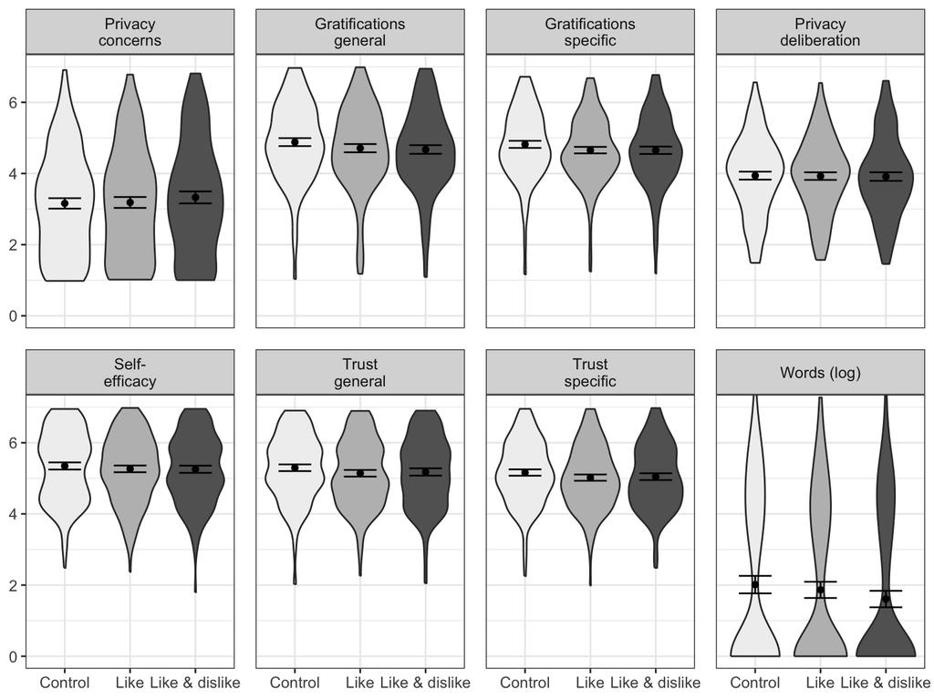

```r
# violin plot
fig_fs_m <-
  ggplot(
    gather(
      d_fs,
      variable,
      value,
      -version) %>%
      mutate(
        variable = factor(
          variable,
          levels = var_names_breaks
          )
        ),
    aes(
      x = version,
      y = value,
      fill = version
      )
    ) +
  geom_violin(
    trim = TRUE
    ) +
  stat_summary(
    fun.y = mean,
    geom = "point"
    ) +
  stat_summary(
    fun.data = mean_se,
    fun.args = list(mult = 1.39),
    geom = "errorbar",
    width = .5
    ) +
  facet_wrap(
    ~ variable,
    nrow = 2
    ) +
  theme_bw() +
  theme(
    axis.title.y = element_blank(),
    axis.title.x = element_blank(),
    plot.title = element_text(hjust = .5),
    panel.spacing = unit(.9, "lines"),
    text = element_text(size = 12),
    legend.position="none",
    legend.title = element_blank()) +
  coord_cartesian(
    ylim = c(0, 7)
    ) +
  scale_fill_brewer(
    palette = "Greys"
    )
ggsave(
  "figures/results/violin_plot.png",
  width = 8,
  height = 6
  )
fig_fs_m
```

#### SEM

In what follows, I also report explicit statistical tests of the differences between the conditions using contrasts.

**Like & Like-Dislike vs. Control**

```r
model <- "
  pri_con =~ PC01_01 + PC01_02 + PC01_04 + PC01_05 + PC01_06 + PC01_07
  grats_gen =~ GR02_01 + GR02_02 + GR02_03 + GR02_04 + GR02_05
  pri_delib =~ PD01_01 + PD01_02 + PD01_03 + PD01_04 + PD01_05
  self_eff =~ SE01_01 + SE01_02 + SE01_03 + SE01_04
  SE01_01 ~~ x*SE01_02
  SE01_03 ~~ x*SE01_04
  trust_community =~ TR01_01 + TR01_02 + TR01_03
  trust_provider =~ TR01_04 + TR01_05 + TR01_06
  trust_system =~ TR01_07 + TR01_08 + TR01_09
  trust_spec =~ trust_community + trust_provider + trust_system

  pri_con + grats_gen + pri_delib + self_eff + trust_spec ~ like + likedislike
  words ~ a*pri_con + b*grats_gen + c*pri_delib + d*self_eff + e*trust_spec + f*like + g*likedislike

# Covariates
words + GR02_01 + GR02_02 + GR02_03 + GR02_04 + GR02_05 + PC01_01 + PC01_02 + PC01_04 + PC01_05 + PC01_06 + PC01_07 + TR01_01 + TR01_02 + TR01_03 + TR01_04 + TR01_05 + TR01_06 + TR01_07 + TR01_08 + TR01_09 + PD01_01 + PD01_02 + PD01_03 + PD01_04 + PD01_05 + SE01_01 + SE01_02 + SE01_03 + SE01_04 ~ male + age + edu
"

fit_lik_ctrl <-
  lavaan::sem(
    model = model,
    data = d,
    estimator = "MLR",
    missing = "ML",
    fixed.x = FALSE
    )

summary(
  fit_lik_ctrl,
  fit = TRUE,
  std = TRUE
  )
```

```
lavaan 0.7-2 ended normally after 605 iterations

  Estimator                                         ML
  Optimization method                           NLMINB
  Number of model parameters                       221
  Number of equality constraints                     1

  Number of observations                           559
  Number of missing patterns                         4

Model Test User Model:
                                              Standard      Scaled
  Test Statistic                              2019.407    1596.343
  Degrees of freedom                               445         445
  P-value (Chi-square)                           0.000       0.000
  Scaling correction factor                                  1.265
    Yuan-Bentler correction (Mplus variant)

Model Test Baseline Model:

  Test statistic                             13359.444   10346.817
  Degrees of freedom                               585         585
  P-value                                        0.000       0.000
  Scaling correction factor                                  1.291

User Model versus Baseline Model:

  Comparative Fit Index (CFI)                    0.877       0.882
  Tucker-Lewis Index (TLI)                       0.838       0.845

  Robust Comparative Fit Index (CFI)                         0.886
  Robust Tucker-Lewis Index (TLI)                            0.850

Loglikelihood and Information Criteria:

  Loglikelihood user model (H0)             -30981.342  -30981.342
  Scaling correction factor                                  1.390
      for the MLR correction
  Loglikelihood unrestricted model (H1)     -29971.639  -29971.639
  Scaling correction factor                                  1.308
```

[output cut: 317 more lines]

```
   .TR01_09            0.592     0.067    8.809    0.000     0.592    0.328
   .words          57409.641 22527.381    2.548    0.011 57409.641    0.921
   .pri_con            2.551     0.144   17.751    0.000     0.998    0.998
   .grats_gen          1.303     0.113   11.534    0.000     0.993    0.993
   .pri_delib          2.080     0.167   12.423    0.000     0.999    0.999
   .self_eff           1.267     0.115   10.995    0.000     0.999    0.999
   .trust_communty     0.311     0.048    6.499    0.000     0.297    0.297
   .trust_provider     0.087     0.038    2.255    0.024     0.077    0.077
   .trust_system      -0.091     0.026   -3.509    0.000    -0.138   -0.138
   .trust_spec         0.729     0.093    7.834    0.000     0.993    0.993
    like               0.227     0.006   36.792    0.000     0.227    1.000
    likedislike        0.216     0.007   29.655    0.000     0.216    1.000
    male               0.250     0.000  817.444    0.000     0.250    1.000
    age              241.746     9.947   24.303    0.000   241.746    1.000
    edu                0.710     0.021   34.591    0.000     0.710    1.000
```

No significant effects of popularity cues on privacy calculus.

**Like-Dislike & Control vs. Like**

```r
model <- "
  pri_con =~ PC01_01 + PC01_02 + PC01_04 + PC01_05 + PC01_06 + PC01_07
  grats_gen =~ GR02_01 + GR02_02 + GR02_03 + GR02_04 + GR02_05
  pri_delib =~ PD01_01 + PD01_02 + PD01_03 + PD01_04 + PD01_05
  self_eff =~ SE01_01 + SE01_02 + SE01_03 + SE01_04
  SE01_01 ~~ x*SE01_02
  SE01_03 ~~ x*SE01_04
  trust_community =~ TR01_01 + TR01_02 + TR01_03
  trust_provider =~ TR01_04 + TR01_05 + TR01_06
  trust_system =~ TR01_07 + TR01_08 + TR01_09
  trust_spec =~ trust_community + trust_provider + trust_system

  pri_con + grats_gen + pri_delib + self_eff + trust_spec + words ~ likedislike + control

# Covariates
words + GR02_01 + GR02_02 + GR02_03 + GR02_04 + GR02_05 + PC01_01 + PC01_02 + PC01_04 + PC01_05 + PC01_06 + PC01_07 + TR01_01 + TR01_02 + TR01_03 + TR01_04 + TR01_05 + TR01_06 + TR01_07 + TR01_08 + TR01_09 + PD01_01 + PD01_02 + PD01_03 + PD01_04 + PD01_05 + SE01_01 + SE01_02 + SE01_03 + SE01_04 ~ male + age + edu
"
fit_lik_ctrl <-
  lavaan::sem(
    model = model,
    data = d,
    estimator = "MLR",
    missing = "ML")

summary(
  fit_lik_ctrl,
  fit = TRUE,
  std = TRUE
  )
```

```
lavaan 0.7-2 ended normally after 550 iterations

  Estimator                                         ML
  Optimization method                           NLMINB
  Number of model parameters                       211
  Number of equality constraints                     1

                                                  Used       Total
  Number of observations                           558         559
  Number of missing patterns                         3

Model Test User Model:
                                              Standard      Scaled
  Test Statistic                              1254.996     994.372
  Degrees of freedom                               435         435
  P-value (Chi-square)                           0.000       0.000
  Scaling correction factor                                  1.262
    Yuan-Bentler correction (Mplus variant)

Model Test Baseline Model:

  Test statistic                             13325.570   10323.740
  Degrees of freedom                               585         585
  P-value                                        0.000       0.000
  Scaling correction factor                                  1.291

User Model versus Baseline Model:

  Comparative Fit Index (CFI)                    0.936       0.943
  Tucker-Lewis Index (TLI)                       0.913       0.923

  Robust Comparative Fit Index (CFI)                         0.945
  Robust Tucker-Lewis Index (TLI)                            0.926

Loglikelihood and Information Criteria:

  Loglikelihood user model (H0)             -26475.947  -26475.947
  Scaling correction factor                                  1.446
      for the MLR correction
  Loglikelihood unrestricted model (H1)     -25848.449  -25848.449
```

[output cut: 309 more lines]

```
   .TR01_04            0.316     0.034    9.416    0.000     0.316    0.220
   .TR01_05            0.519     0.053    9.733    0.000     0.519    0.388
   .TR01_06            0.448     0.042   10.621    0.000     0.448    0.366
   .TR01_07            0.741     0.057   13.002    0.000     0.741    0.535
   .TR01_08            0.956     0.079   12.044    0.000     0.956    0.569
   .TR01_09            0.533     0.061    8.675    0.000     0.533    0.294
   .words          62215.796 24208.074    2.570    0.010 62215.796    0.993
   .pri_con            2.538     0.144   17.630    0.000     0.997    0.997
   .grats_gen          1.268     0.114   11.158    0.000     0.994    0.994
   .pri_delib          2.183     0.158   13.843    0.000     0.999    0.999
   .self_eff           1.233     0.114   10.832    0.000     0.999    0.999
   .trust_communty     0.298     0.045    6.656    0.000     0.282    0.282
   .trust_provider     0.100     0.031    3.198    0.001     0.089    0.089
   .trust_system      -0.077     0.019   -4.050    0.000    -0.120   -0.120
   .trust_spec         0.753     0.095    7.910    0.000     0.992    0.992
```

No significant effects of popularity cues on privacy calculus.

## Exploratory analyses

The bivariate relations showed several strong correlations. People who trusted the providers more also experienced more gratifications (*r* = .79). In multiple regression, we analze the potential effect of one variable on the outcome while holding all others constant. In this case, I tested whether trust increases communication while holding constant gratifications, privacy concerns, privacy deliberations, and self-efficacy. Given the close theoretical and empirical interrelations between the predictors, this creates an unlikely and artifical scenario. If people say loose trust in a provider, they will likely experience more concerns and less benefits. But it is not even necessary to control for these mediating factors. When trying to analyze the causal effect, it is necessary to control for counfounding variables, but importantly not for mediators (Rohrer 2018). Confunding variables impact both the independent variable and the outcome. Sociodemographic variables are often ideal candidates for confounders. For example, men are generally less concerned about their privacy and post more online. Hence, controlling for gender hence helps isolate the actual causal effect. As a result, I reran the analyses controlling for confounding variables that are not mediators.

### Experimental Factors

#### Words

I first compare likes and likes plus dislikes to the control condition.

```
Some PIT values larger than 1! Largest:  1
Rounding PIT > 1 to 1.
```

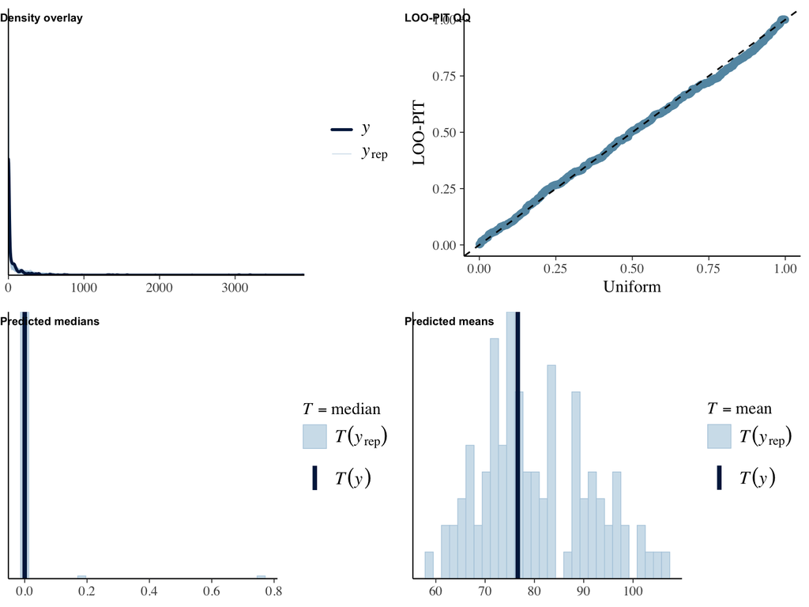

```
 Family: hurdle_gamma
  Links: mu = log; hu = logit
Formula: words ~ 1 + age + male + edu + version
         hu ~ 1 + age + male + edu + version
   Data: object (Number of observations: 558)
  Draws: 4 chains, each with iter = 1000; warmup = 500; thin = 1;
         total post-warmup draws = 2000

Regression Coefficients:
                       Estimate Est.Error l-95% CI u-95% CI Rhat Bulk_ESS Tail_ESS
Intercept                  5.61      0.36     4.90     6.33 1.00     3234     1854
hu_Intercept               1.06      0.37     0.29     1.78 1.00     4426     1308
age                       -0.00      0.01    -0.01     0.01 1.00     3751     1519
male                      -0.18      0.16    -0.49     0.12 1.00     3402     1398
edu                        0.01      0.09    -0.15     0.19 1.00     3654     1326
versionLike               -0.39      0.18    -0.75    -0.02 1.00     2466     1494
versionLike&dislike       -0.47      0.20    -0.86    -0.07 1.00     2227     1396
hu_age                    -0.01      0.01    -0.02     0.00 1.00     5188     1608
hu_male                   -0.06      0.17    -0.39     0.29 1.00     3739     1271
hu_edu                    -0.21      0.10    -0.41    -0.02 1.00     3714     1538
hu_versionLike             0.02      0.21    -0.39     0.44 1.00     2764     1822
hu_versionLike&dislike     0.24      0.22    -0.18     0.65 1.00     2816     1576

Further Distributional Parameters:
      Estimate Est.Error l-95% CI u-95% CI Rhat Bulk_ESS Tail_ESS
shape     0.70      0.05     0.60     0.81 1.00     3406     1469

Draws were sampled using sampling(NUTS). For each parameter, Bulk_ESS
and Tail_ESS are effective sample size measures, and Rhat is the potential
scale reduction factor on split chains (at convergence, Rhat = 1).
```

```
Results of marginal effects:
  Outcome    term                 contrast estimate conf.low conf.high
1   words     age                    dY/dX    0.263   -0.791      1.28
2   words     edu                    dY/dX    9.862   -5.765     28.21
3   words    male                    1 - 0  -11.141  -42.035     17.56
4   words version Like & dislike - Control  -47.401  -93.564    -11.24
5   words version           Like - Control  -34.964  -76.826      2.27
```

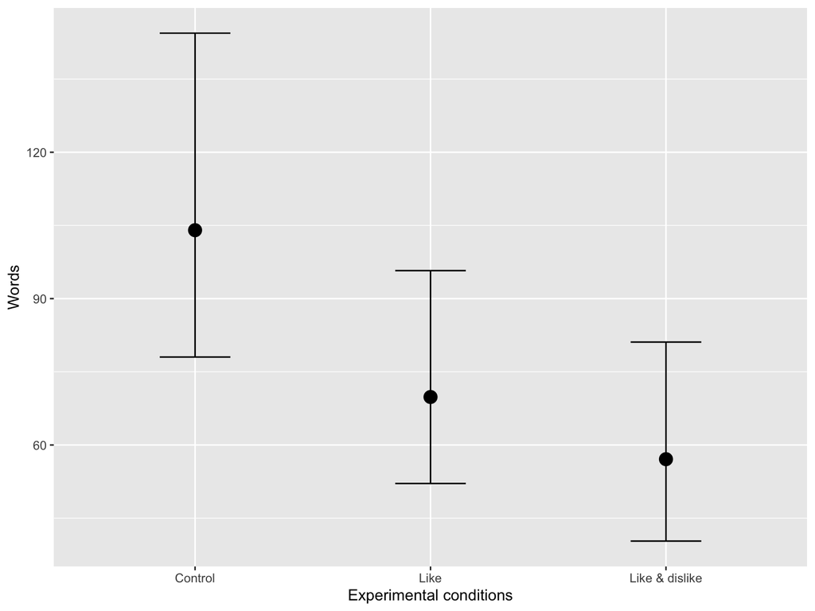

```r
run_hurdles(
  object = d,
  name = "wrds_ctrl",
  outcome = "words",
  predictor = "version",
  y_lab = "Words",
  x_lab = "Experimental conditions"
  )
```

Let’s find out by how much people in like and like plus dislike condition wrote fewer words.

```r
words_m_ctrl <-
  fig_wrds_ctrl$data %>%
  filter(effect1__ == "Control") %>%
  select(estimate__)

words_m_lk <-
  fig_wrds_ctrl$data %>%
  filter(effect1__ == "Like") %>%
  select(estimate__)

words_m_lkdslk <-
  fig_wrds_ctrl$data %>%
  filter(effect1__ == "Like & dislike") %>%
  select(estimate__)

effect_lk_wrds <- words_m_ctrl - words_m_lk
effect_lkdslk_wrds <- words_m_ctrl - words_m_lkdslk

effect_lk_prcnt <-
  (effect_lk_wrds / words_m_ctrl) * 100 %>%
  round()
effect_lkdlk_prcnt <-
  (effect_lkdslk_wrds / words_m_ctrl) * 100 %>%
  round()
```

Compared to the control condition, participants wrote 45.117 percent fewer words on the platform with likes and dislikes.

```
Some PIT values larger than 1! Largest:  1
Rounding PIT > 1 to 1.
```

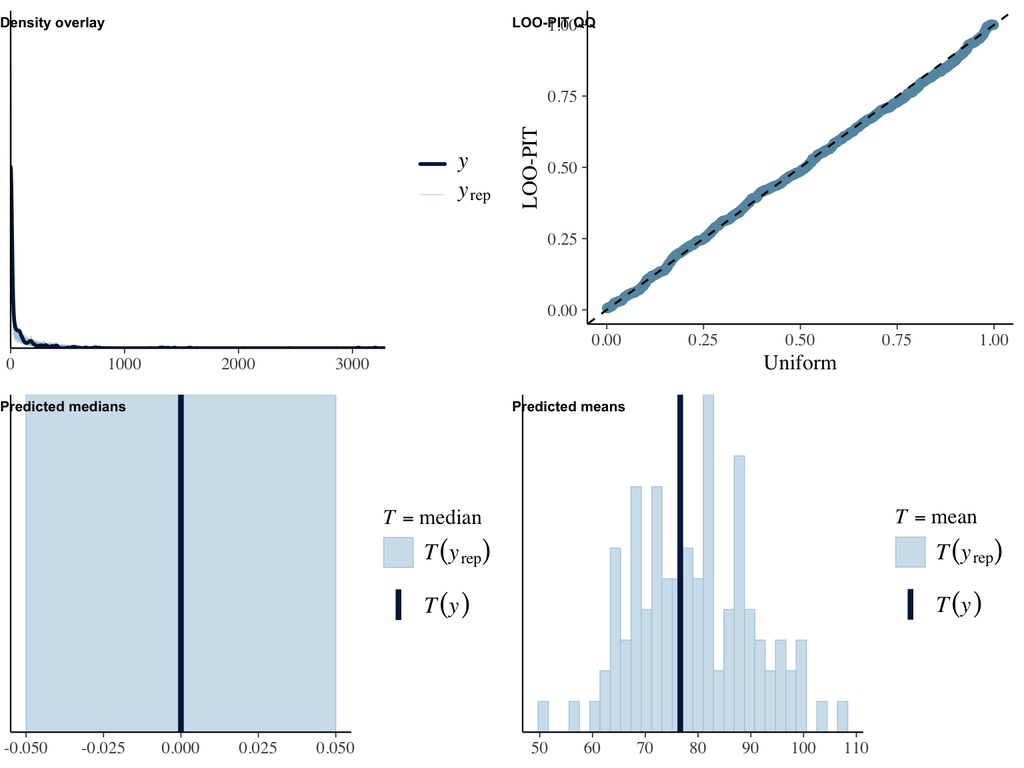

```
 Family: hurdle_gamma
  Links: mu = log; hu = logit
Formula: words ~ 1 + age + male + edu + version_lkdslk
         hu ~ 1 + age + male + edu + version_lkdslk
   Data: object (Number of observations: 558)
  Draws: 4 chains, each with iter = 1000; warmup = 500; thin = 1;
         total post-warmup draws = 2000

Regression Coefficients:
                         Estimate Est.Error l-95% CI u-95% CI Rhat Bulk_ESS Tail_ESS
Intercept                    5.16      0.37     4.43     5.90 1.00     3166     1759
hu_Intercept                 1.29      0.38     0.55     2.03 1.01     3972     1725
age                         -0.00      0.01    -0.01     0.01 1.00     4589     1442
male                        -0.18      0.16    -0.49     0.13 1.00     3460     1617
edu                          0.01      0.09    -0.18     0.20 1.00     3683     1514
version_lkdslkLike           0.07      0.21    -0.35     0.49 1.00     2305     1510
version_lkdslkControl        0.46      0.21     0.04     0.86 1.00     2285     1519
hu_age                      -0.01      0.01    -0.02     0.00 1.00     5272     1382
hu_male                     -0.06      0.18    -0.42     0.28 1.00     3969     1562
hu_edu                      -0.20      0.11    -0.42     0.01 1.00     3806     1712
hu_version_lkdslkLike       -0.21      0.22    -0.63     0.21 1.00     2966     1889
hu_version_lkdslkControl    -0.23      0.23    -0.66     0.23 1.00     2512     1331

Further Distributional Parameters:
      Estimate Est.Error l-95% CI u-95% CI Rhat Bulk_ESS Tail_ESS
shape     0.70      0.06     0.59     0.81 1.00     3992     1411

Draws were sampled using sampling(NUTS). For each parameter, Bulk_ESS
and Tail_ESS are effective sample size measures, and Rhat is the potential
scale reduction factor on split chains (at convergence, Rhat = 1).
```

```
Results of marginal effects:
  Outcome           term                 contrast estimate conf.low conf.high
1   words            age                    dY/dX    0.232   -0.736      1.24
2   words            edu                    dY/dX    9.776   -7.683     28.32
3   words           male                    1 - 0  -11.008  -42.074     19.15
4   words version_lkdslk Control - Like & dislike   47.228    9.524     92.32
5   words version_lkdslk    Like - Like & dislike   12.596  -20.138     44.51
```

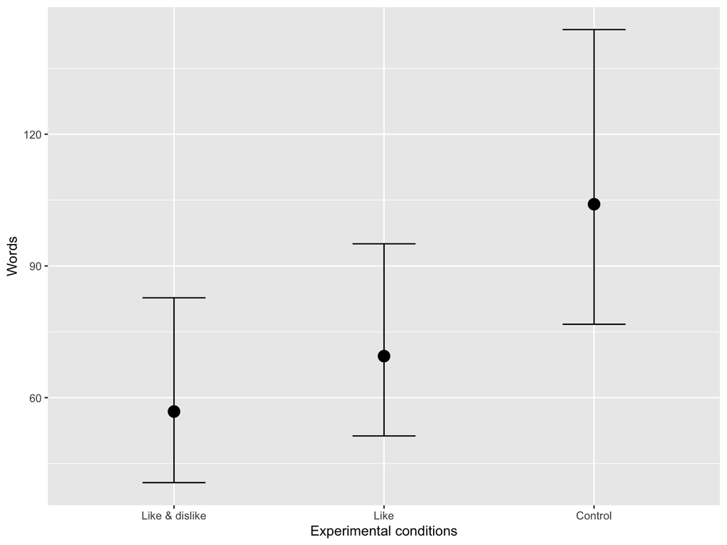

```r
run_hurdles(
  object = d,
  name = "wrds_lkdslk",
  outcome = "words",
  predictor = "version_lkdslk",
  y_lab = "Words",
  x_lab = "Experimental conditions"
  )
```

#### Privacy Concerns

I first compare likes and likes plus dislikes to the control condition.

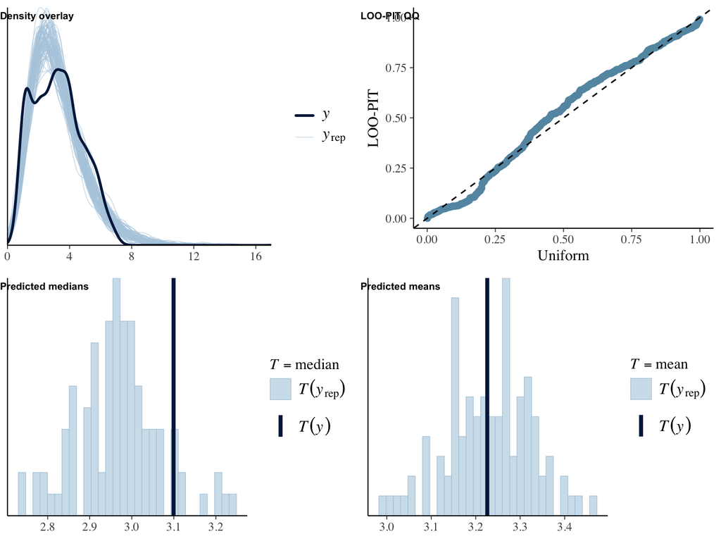

```
 Family: hurdle_gamma
  Links: mu = log; hu = logit
Formula: pri_con_fs ~ 1 + age + male + edu + version
         hu ~ 1 + age + male + edu + version
   Data: object (Number of observations: 558)
  Draws: 4 chains, each with iter = 1000; warmup = 500; thin = 1;
         total post-warmup draws = 2000

Regression Coefficients:
                       Estimate Est.Error l-95% CI u-95% CI Rhat Bulk_ESS Tail_ESS
Intercept                  1.21      0.09     1.04     1.39 1.00     2013     1535
hu_Intercept              -9.79      6.11   -23.96     0.11 1.00     1470      979
age                       -0.00      0.00    -0.00     0.00 1.00     1818     1192
male                      -0.06      0.04    -0.14     0.03 1.00     2123     1207
edu                        0.03      0.03    -0.02     0.08 1.00     2321     1513
versionLike                0.01      0.05    -0.08     0.11 1.00     1617     1430
versionLike&dislike        0.06      0.05    -0.04     0.15 1.00     1659     1476
hu_age                     0.00      0.08    -0.15     0.17 1.01     1499     1097
hu_male                   -0.23      2.96    -6.96     5.73 1.00     1560     1231
hu_edu                    -0.10      1.64    -3.56     3.18 1.00     1705     1297
hu_versionLike             0.02      4.10    -8.30     9.27 1.00     1130      847
hu_versionLike&dislike    -0.23      4.29    -9.24     8.82 1.00     1017      799

Further Distributional Parameters:
      Estimate Est.Error l-95% CI u-95% CI Rhat Bulk_ESS Tail_ESS
shape     3.94      0.24     3.49     4.41 1.00     1886     1234

Draws were sampled using sampling(NUTS). For each parameter, Bulk_ESS
and Tail_ESS are effective sample size measures, and Rhat is the potential
scale reduction factor on split chains (at convergence, Rhat = 1).
```

```
Results of marginal effects:
     Outcome    term                 contrast estimate conf.low conf.high
1 pri_con_fs     age                    dY/dX -0.00605  -0.0147   0.00278
2 pri_con_fs     edu                    dY/dX  0.08560  -0.0789   0.25328
3 pri_con_fs    male                    1 - 0 -0.18201  -0.4376   0.08089
4 pri_con_fs version Like & dislike - Control  0.18429  -0.1279   0.49961
5 pri_con_fs version           Like - Control  0.04200  -0.2603   0.35838
```

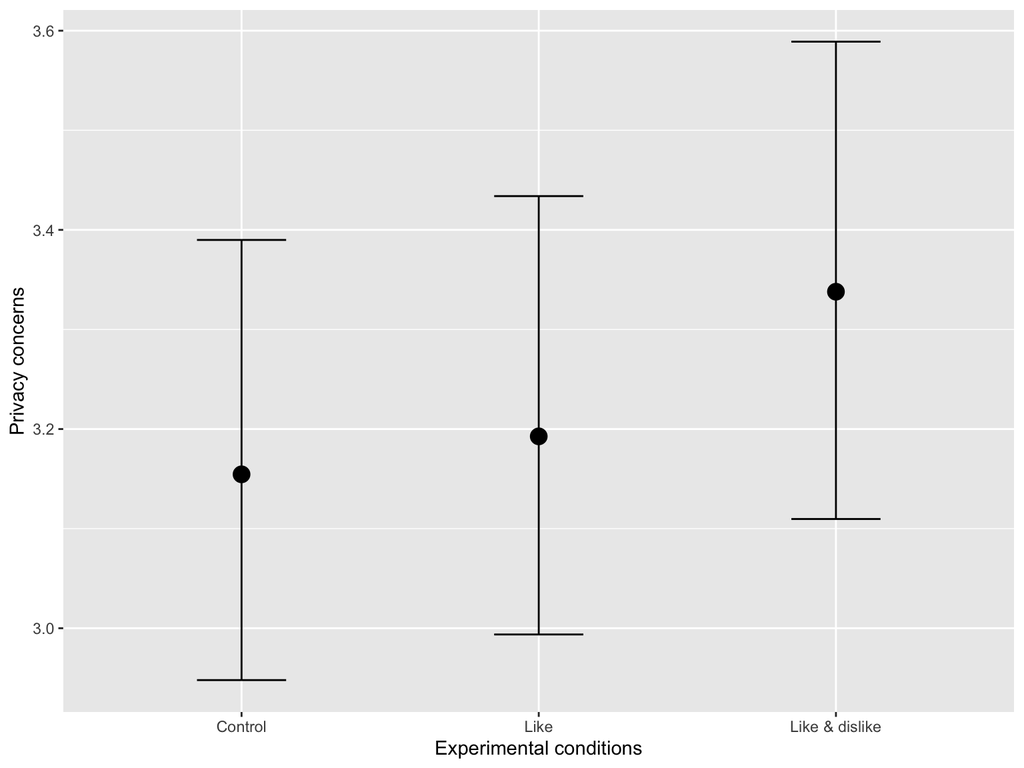

```r
run_hurdles(
  object = d,
  name = "pricon_ctrl",
  outcome = "pri_con_fs",
  predictor = "version",
  y_lab = "Privacy concerns",
  x_lab = "Experimental conditions"
  )
```

I then compare the likes and control conditions to the likes plus dislikes condition.

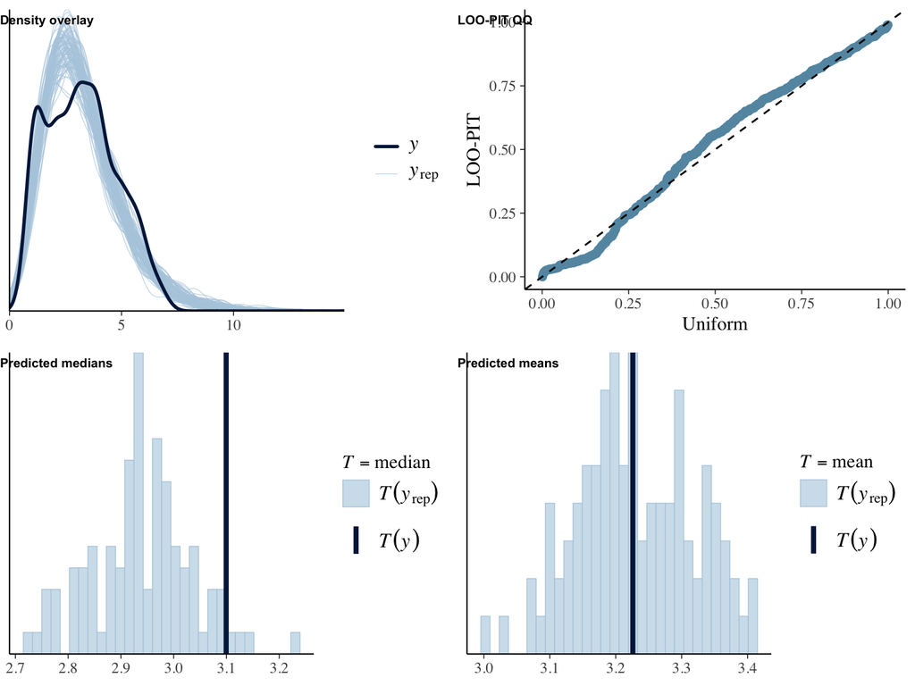

```
 Family: hurdle_gamma
  Links: mu = log; hu = logit
Formula: pri_con_fs ~ 1 + age + male + edu + version_lkdslk
         hu ~ 1 + age + male + edu + version_lkdslk
   Data: object (Number of observations: 558)
  Draws: 4 chains, each with iter = 1000; warmup = 500; thin = 1;
         total post-warmup draws = 2000

Regression Coefficients:
                         Estimate Est.Error l-95% CI u-95% CI Rhat Bulk_ESS Tail_ESS
Intercept                    1.27      0.09     1.09     1.44 1.00     1836     1470
hu_Intercept               -10.40      6.00   -23.37    -0.64 1.00     1103     1240
age                         -0.00      0.00    -0.00     0.00 1.00     2072     1186
male                        -0.05      0.04    -0.14     0.03 1.00     1765     1376
edu                          0.03      0.03    -0.02     0.07 1.00     1868     1401
version_lkdslkLike          -0.04      0.05    -0.15     0.06 1.00     1572     1431
version_lkdslkControl       -0.06      0.05    -0.16     0.05 1.00     1441     1330
hu_age                       0.01      0.08    -0.14     0.17 1.00     1347     1243
hu_male                     -0.14      3.04    -6.11     6.34 1.00     1484      916
hu_edu                      -0.19      1.69    -3.88     3.07 1.00     1412     1176
hu_version_lkdslkLike        0.21      4.74    -9.45    10.32 1.00      783      705
hu_version_lkdslkControl     0.39      4.61    -8.58    10.96 1.01      777      716

Further Distributional Parameters:
      Estimate Est.Error l-95% CI u-95% CI Rhat Bulk_ESS Tail_ESS
shape     3.94      0.23     3.49     4.39 1.00     1655     1202

Draws were sampled using sampling(NUTS). For each parameter, Bulk_ESS
and Tail_ESS are effective sample size measures, and Rhat is the potential
scale reduction factor on split chains (at convergence, Rhat = 1).
```

```
Results of marginal effects:
     Outcome           term                 contrast estimate conf.low conf.high
1 pri_con_fs            age                    dY/dX  -0.0060  -0.0152   0.00327
2 pri_con_fs            edu                    dY/dX   0.0828  -0.0737   0.24298
3 pri_con_fs           male                    1 - 0  -0.1795  -0.4396   0.10196
4 pri_con_fs version_lkdslk Control - Like & dislike  -0.1872  -0.5205   0.15964
5 pri_con_fs version_lkdslk    Like - Like & dislike  -0.1450  -0.4845   0.19546
```

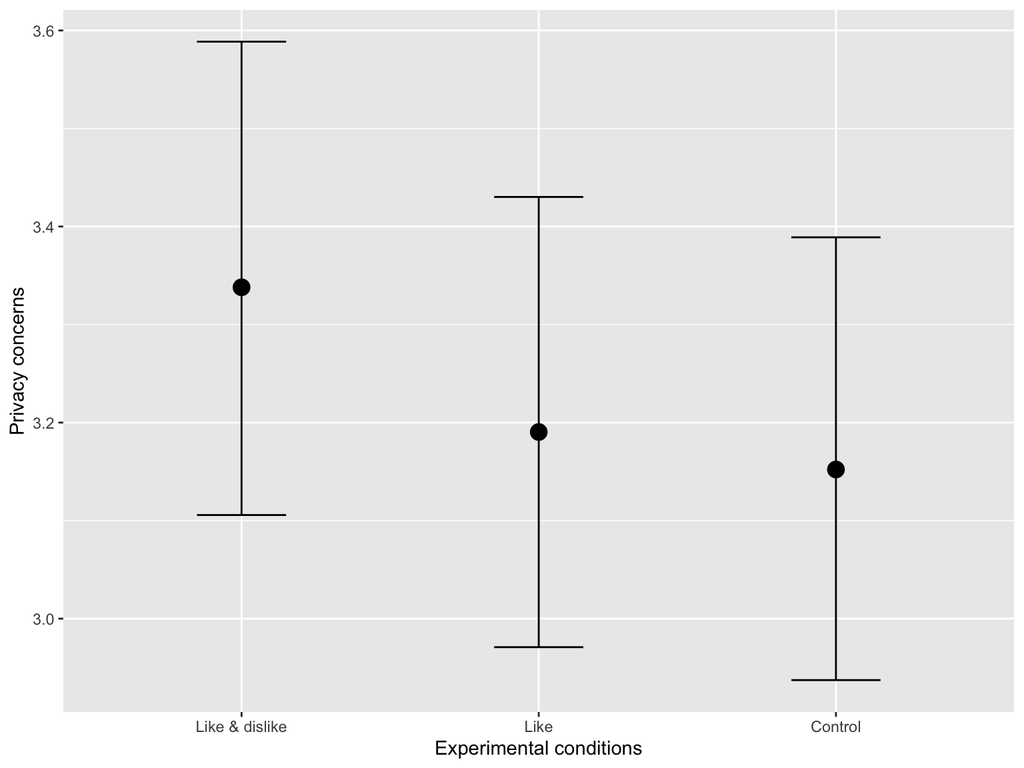

```r
run_hurdles(
  object = d,
  name = "pricon_lkdslk",
  outcome = "pri_con_fs",
  predictor = "version_lkdslk",
  y_lab = "Privacy concerns",
  x_lab = "Experimental conditions"
  )
```

#### Gratifications General

I first compare likes and likes plus dislikes to the control condition.

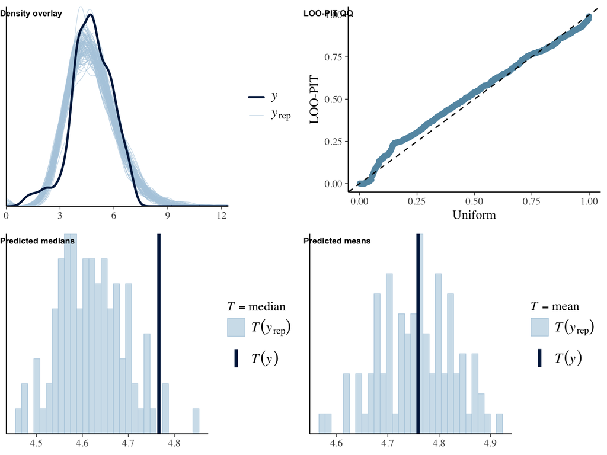

```
 Family: hurdle_gamma
  Links: mu = log; hu = logit
Formula: grats_gen_fs ~ 1 + age + male + edu + version
         hu ~ 1 + age + male + edu + version
   Data: object (Number of observations: 558)
  Draws: 4 chains, each with iter = 1000; warmup = 500; thin = 1;
         total post-warmup draws = 2000

Regression Coefficients:
                       Estimate Est.Error l-95% CI u-95% CI Rhat Bulk_ESS Tail_ESS
Intercept                  1.60      0.05     1.50     1.69 1.00     2290     1777
hu_Intercept              -9.60      6.24   -24.81     0.91 1.00     1459     1155
age                        0.00      0.00    -0.00     0.00 1.00     2267     1256
male                      -0.01      0.02    -0.06     0.03 1.00     2026     1472
edu                       -0.01      0.01    -0.04     0.02 1.01     2693      996
versionLike               -0.04      0.03    -0.09     0.02 1.00     1774     1426
versionLike&dislike       -0.04      0.03    -0.10     0.01 1.01     1796     1299
hu_age                     0.00      0.09    -0.17     0.19 1.00     1902     1087
hu_male                   -0.20      3.15    -6.59     5.77 1.00     1777      998
hu_edu                    -0.26      1.69    -4.36     2.87 1.00     1570      909
hu_versionLike            -0.32      4.31    -9.17     8.98 1.00     1387     1224
hu_versionLike&dislike    -0.62      4.55    -9.98     8.50 1.00     1296     1082

Further Distributional Parameters:
      Estimate Est.Error l-95% CI u-95% CI Rhat Bulk_ESS Tail_ESS
shape    13.74      0.78    12.23    15.29 1.00     2202     1522

Draws were sampled using sampling(NUTS). For each parameter, Bulk_ESS
and Tail_ESS are effective sample size measures, and Rhat is the potential
scale reduction factor on split chains (at convergence, Rhat = 1).
```

```
Results of marginal effects:
       Outcome    term                 contrast estimate conf.low conf.high
1 grats_gen_fs     age                    dY/dX  0.00142 -0.00594   0.00849
2 grats_gen_fs     edu                    dY/dX -0.04946 -0.18615   0.09184
3 grats_gen_fs    male                    1 - 0 -0.06622 -0.28747   0.15746
4 grats_gen_fs version Like & dislike - Control -0.20108 -0.48151   0.05616
5 grats_gen_fs version           Like - Control -0.17207 -0.42047   0.08949
```

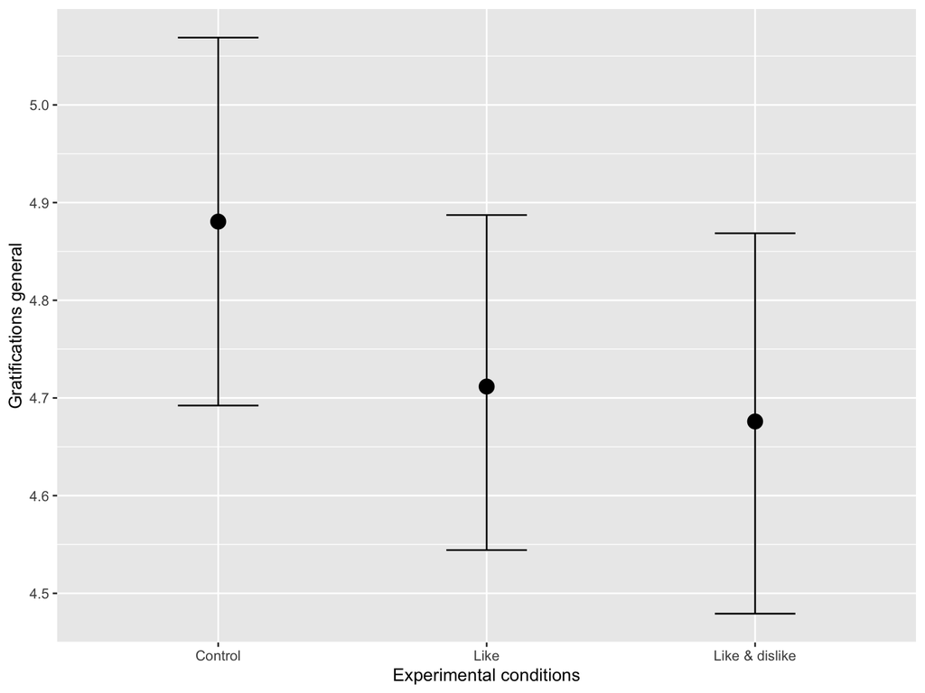

```r
run_hurdles(
  object = d,
  name = "grats_ctrl",
  outcome = "grats_gen_fs",
  predictor = "version",
  y_lab = "Gratifications general",
  x_lab = "Experimental conditions"
  )
```

I then compare the likes and control conditions to the likes plus dislikes condition.

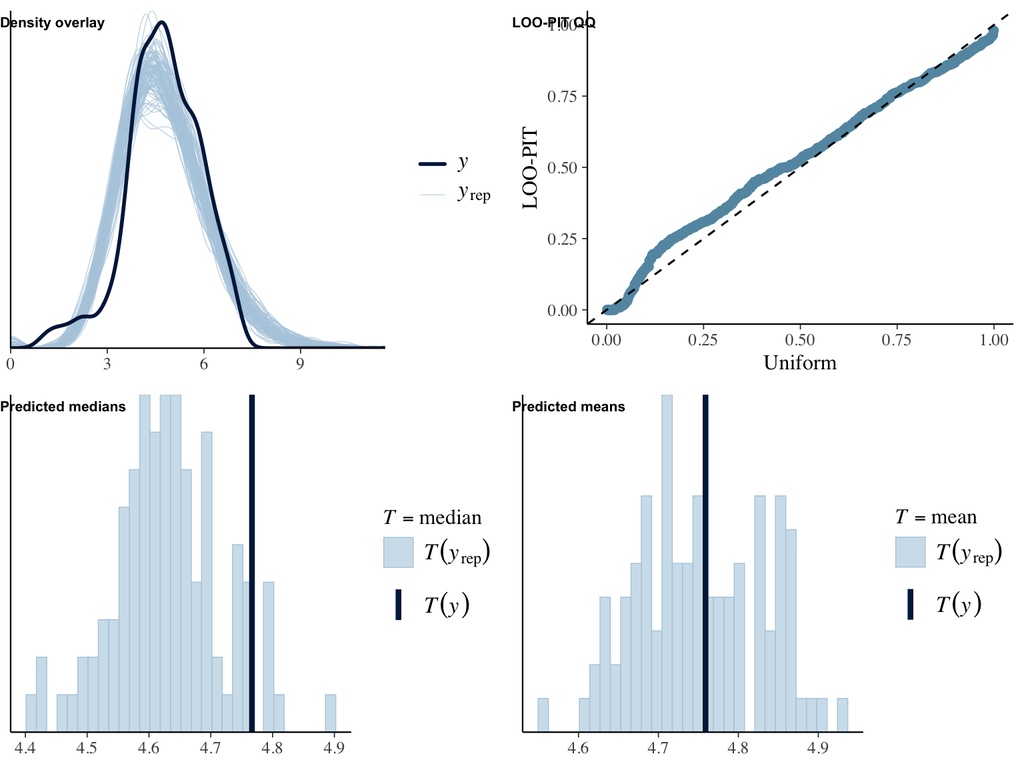

```
 Family: hurdle_gamma
  Links: mu = log; hu = logit
Formula: grats_gen_fs ~ 1 + age + male + edu + version_lkdslk
         hu ~ 1 + age + male + edu + version_lkdslk
   Data: object (Number of observations: 558)
  Draws: 4 chains, each with iter = 1000; warmup = 500; thin = 1;
         total post-warmup draws = 2000

Regression Coefficients:
                         Estimate Est.Error l-95% CI u-95% CI Rhat Bulk_ESS Tail_ESS
Intercept                    1.56      0.05     1.46     1.65 1.00     2403     1672
hu_Intercept               -10.18      6.21   -24.17     0.07 1.00     1202      943
age                          0.00      0.00    -0.00     0.00 1.00     2460     1267
male                        -0.01      0.02    -0.06     0.03 1.00     2233     1450
edu                         -0.01      0.01    -0.04     0.02 1.00     2557     1339
version_lkdslkLike           0.01      0.03    -0.05     0.06 1.00     1851     1568
version_lkdslkControl        0.04      0.03    -0.01     0.10 1.00     1929     1494
hu_age                       0.00      0.08    -0.15     0.17 1.00     1582     1278
hu_male                     -0.17      3.07    -6.79     6.14 1.00     1615      937
hu_edu                      -0.15      1.67    -3.75     3.15 1.00     1800     1182
hu_version_lkdslkLike        0.22      4.43    -8.58     9.53 1.00     1183      784
hu_version_lkdslkControl     0.22      4.62    -9.28     9.80 1.01     1128      838

Further Distributional Parameters:
      Estimate Est.Error l-95% CI u-95% CI Rhat Bulk_ESS Tail_ESS
shape    13.74      0.82    12.21    15.33 1.00     2314     1467

Draws were sampled using sampling(NUTS). For each parameter, Bulk_ESS
and Tail_ESS are effective sample size measures, and Rhat is the potential
scale reduction factor on split chains (at convergence, Rhat = 1).
```

```
Results of marginal effects:
       Outcome           term                 contrast estimate conf.low conf.high
1 grats_gen_fs            age                    dY/dX  0.00128 -0.00567   0.00851
2 grats_gen_fs            edu                    dY/dX -0.04933 -0.18313   0.08241
3 grats_gen_fs           male                    1 - 0 -0.07248 -0.29699   0.15462
4 grats_gen_fs version_lkdslk Control - Like & dislike  0.20867 -0.07211   0.47981
5 grats_gen_fs version_lkdslk    Like - Like & dislike  0.03465 -0.23034   0.30254
```

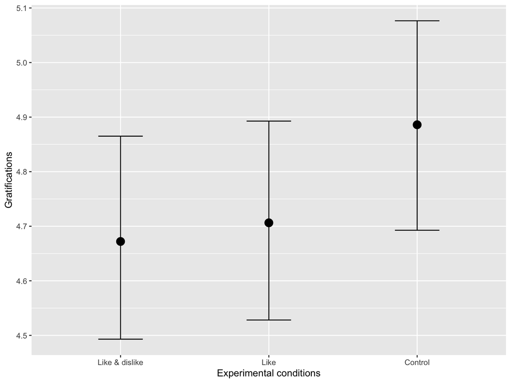

```r
run_hurdles(
  object = d,
  name = "grats_lkdslk",
  outcome = "grats_gen_fs",
  predictor = "version_lkdslk",
  y_lab = "Gratifications",
  x_lab = "Experimental conditions"
  )
```

#### Privacy Deliberation

I first compare likes and likes plus dislikes to the control condition.

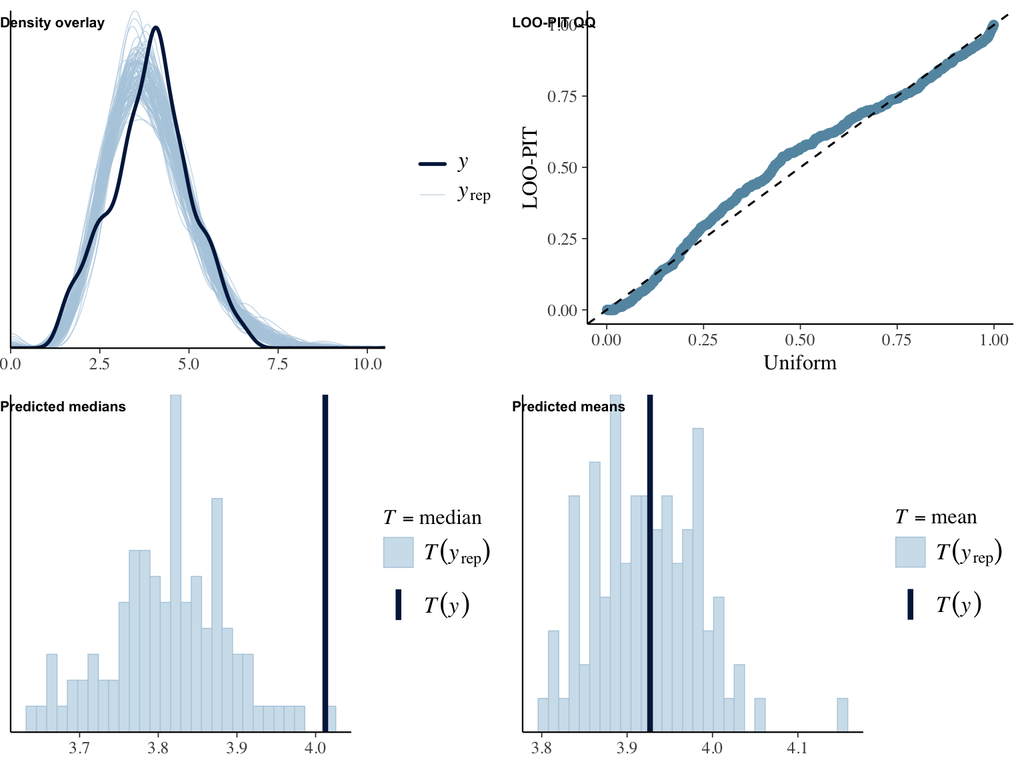

```
 Family: hurdle_gamma
  Links: mu = log; hu = logit
Formula: pri_del_fs ~ 1 + age + male + edu + version
         hu ~ 1 + age + male + edu + version
   Data: object (Number of observations: 558)
  Draws: 4 chains, each with iter = 1000; warmup = 500; thin = 1;
         total post-warmup draws = 2000

Regression Coefficients:
                       Estimate Est.Error l-95% CI u-95% CI Rhat Bulk_ESS Tail_ESS
Intercept                  1.50      0.05     1.40     1.61 1.00     2033     1773
hu_Intercept              -9.75      5.84   -23.19     0.10 1.00     1372     1176
age                       -0.00      0.00    -0.00    -0.00 1.00     2218     1692
male                      -0.05      0.03    -0.10    -0.00 1.00     2065     1529
edu                        0.00      0.01    -0.02     0.03 1.00     2498     1380
versionLike               -0.00      0.03    -0.06     0.06 1.00     1635     1380
versionLike&dislike       -0.01      0.03    -0.07     0.05 1.00     1748     1228
hu_age                     0.00      0.08    -0.14     0.16 1.01     2083     1321
hu_male                   -0.03      3.08    -6.06     6.46 1.00     1764     1171
hu_edu                    -0.23      1.68    -4.20     2.68 1.00     1453     1175
hu_versionLike            -0.13      4.44    -9.51     9.05 1.00     1034      923
hu_versionLike&dislike    -0.42      4.62   -10.36     8.80 1.00     1038      885

Further Distributional Parameters:
      Estimate Est.Error l-95% CI u-95% CI Rhat Bulk_ESS Tail_ESS
shape    11.44      0.69    10.09    12.82 1.00     2110     1380

Draws were sampled using sampling(NUTS). For each parameter, Bulk_ESS
and Tail_ESS are effective sample size measures, and Rhat is the potential
scale reduction factor on split chains (at convergence, Rhat = 1).
```

```
Results of marginal effects:
     Outcome    term                 contrast estimate conf.low conf.high
1 pri_del_fs     age                    dY/dX -0.00936  -0.0158  -0.00286
2 pri_del_fs     edu                    dY/dX  0.01439  -0.1015   0.12649
3 pri_del_fs    male                    1 - 0 -0.20921  -0.3914  -0.00391
4 pri_del_fs version Like & dislike - Control -0.03976  -0.2938   0.18859
5 pri_del_fs version           Like - Control -0.00390  -0.2429   0.23193
```

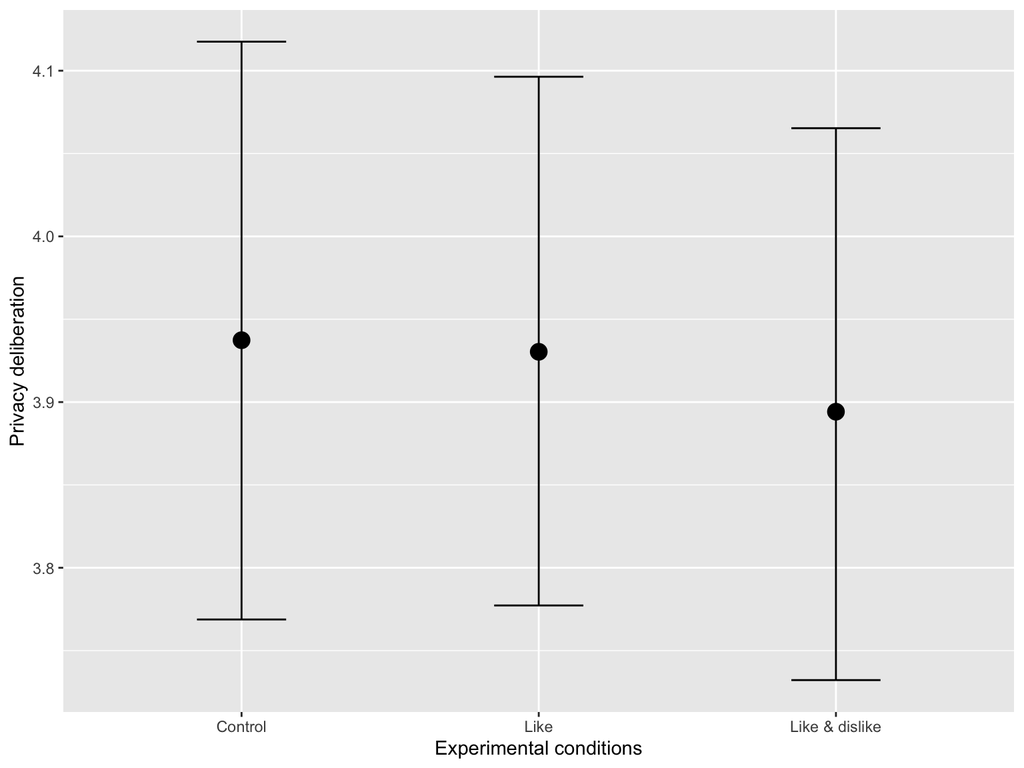

```r
run_hurdles(
  object = d,
  name = "pridel_ctrl",
  outcome = "pri_del_fs",
  predictor = "version",
  y_lab = "Privacy deliberation",
  x_lab = "Experimental conditions"
  )
```

I then compare the likes and control conditions to the likes plus dislikes condition.

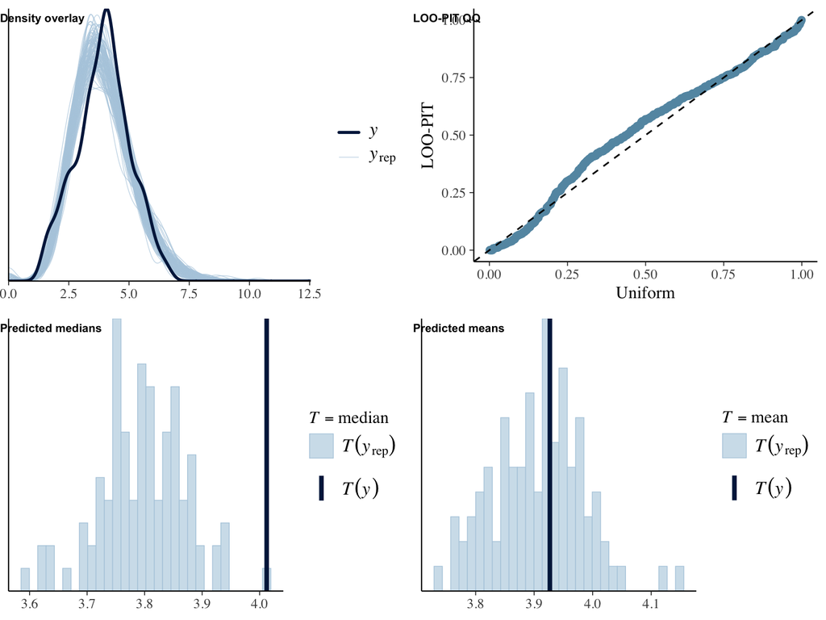

```
 Family: hurdle_gamma
  Links: mu = log; hu = logit
Formula: pri_del_fs ~ 1 + age + male + edu + version_lkdslk
         hu ~ 1 + age + male + edu + version_lkdslk
   Data: object (Number of observations: 558)
  Draws: 4 chains, each with iter = 1000; warmup = 500; thin = 1;
         total post-warmup draws = 2000

Regression Coefficients:
                         Estimate Est.Error l-95% CI u-95% CI Rhat Bulk_ESS Tail_ESS
Intercept                    1.49      0.05     1.38     1.60 1.01     2150     1494
hu_Intercept               -10.15      6.37   -24.83    -0.11 1.01     1452     1287
age                         -0.00      0.00    -0.00    -0.00 1.01     1831     1201
male                        -0.05      0.02    -0.10    -0.01 1.00     2388     1266
edu                          0.00      0.02    -0.03     0.03 1.00     2118     1471
version_lkdslkLike           0.01      0.03    -0.05     0.07 1.00     2022     1463
version_lkdslkControl        0.01      0.03    -0.05     0.07 1.00     2100     1342
hu_age                       0.00      0.08    -0.16     0.18 1.00     1991     1210
hu_male                     -0.30      3.56    -7.92     6.44 1.00     1281      588
hu_edu                      -0.20      1.76    -4.22     3.03 1.00     1506      988
hu_version_lkdslkLike        0.17      4.41    -9.33     9.58 1.00     1177      805
hu_version_lkdslkControl     0.22      4.54    -9.27     9.68 1.00     1141      943

Further Distributional Parameters:
      Estimate Est.Error l-95% CI u-95% CI Rhat Bulk_ESS Tail_ESS
shape    11.41      0.67    10.18    12.73 1.00     2217     1564

Draws were sampled using sampling(NUTS). For each parameter, Bulk_ESS
and Tail_ESS are effective sample size measures, and Rhat is the potential
scale reduction factor on split chains (at convergence, Rhat = 1).
```

```
Results of marginal effects:
     Outcome           term                 contrast estimate conf.low conf.high
1 pri_del_fs            age                    dY/dX -0.00944  -0.0159  -0.00247
2 pri_del_fs            edu                    dY/dX  0.01257  -0.1049   0.13016
3 pri_del_fs           male                    1 - 0 -0.20711  -0.4032  -0.01654
4 pri_del_fs version_lkdslk Control - Like & dislike  0.04242  -0.1933   0.28131
5 pri_del_fs version_lkdslk    Like - Like & dislike  0.03798  -0.2046   0.27192
```

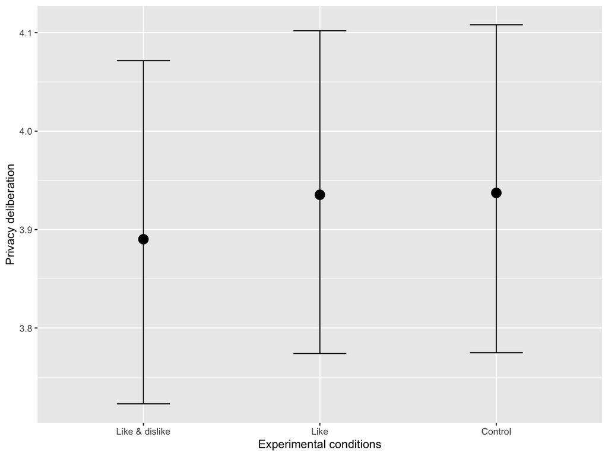

```r
run_hurdles(
  object = d,
  name = "pridel_lkdslk",
  outcome = "pri_del_fs",
  predictor = "version_lkdslk",
  y_lab = "Privacy deliberation",
  x_lab = "Experimental conditions"
  )
```

#### Trust general

I first compare likes and likes plus dislikes to the control condition.

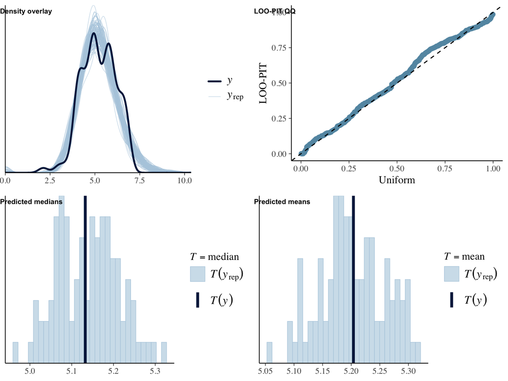

```
 Family: hurdle_gamma
  Links: mu = log; hu = logit
Formula: trust_gen_fs ~ 1 + age + male + edu + version
         hu ~ 1 + age + male + edu + version
   Data: object (Number of observations: 558)
  Draws: 4 chains, each with iter = 1000; warmup = 500; thin = 1;
         total post-warmup draws = 2000

Regression Coefficients:
                       Estimate Est.Error l-95% CI u-95% CI Rhat Bulk_ESS Tail_ESS
Intercept                  1.69      0.03     1.63     1.76 1.00     2153     1848
hu_Intercept             -10.18      6.22   -24.15    -0.10 1.01     1021     1073
age                       -0.00      0.00    -0.00     0.00 1.00     1899     1384
male                       0.00      0.02    -0.03     0.03 1.00     2078     1636
edu                       -0.00      0.01    -0.02     0.02 1.00     2795     1393
versionLike               -0.03      0.02    -0.07     0.01 1.00     1582     1606
versionLike&dislike       -0.02      0.02    -0.06     0.01 1.01     1618     1511
hu_age                     0.01      0.08    -0.16     0.18 1.00     1098     1107
hu_male                   -0.21      3.12    -7.01     6.31 1.00     1049      786
hu_edu                    -0.11      1.68    -3.57     3.36 1.00     1257     1186
hu_versionLike            -0.02      4.51    -9.32     9.50 1.00      778      603
hu_versionLike&dislike    -0.29      4.93   -11.02    10.10 1.01      742      603

Further Distributional Parameters:
      Estimate Est.Error l-95% CI u-95% CI Rhat Bulk_ESS Tail_ESS
shape    27.44      1.72    24.29    30.91 1.00     2087     1627

Draws were sampled using sampling(NUTS). For each parameter, Bulk_ESS
and Tail_ESS are effective sample size measures, and Rhat is the potential
scale reduction factor on split chains (at convergence, Rhat = 1).
```

```
Results of marginal effects:
       Outcome    term                 contrast  estimate conf.low conf.high
1 trust_gen_fs     age                    dY/dX -0.003025 -0.00885   0.00247
2 trust_gen_fs     edu                    dY/dX -0.000231 -0.10766   0.10892
3 trust_gen_fs    male                    1 - 0  0.016718 -0.15426   0.18288
4 trust_gen_fs version Like & dislike - Control -0.129307 -0.33479   0.07744
5 trust_gen_fs version           Like - Control -0.149155 -0.35150   0.04719
```

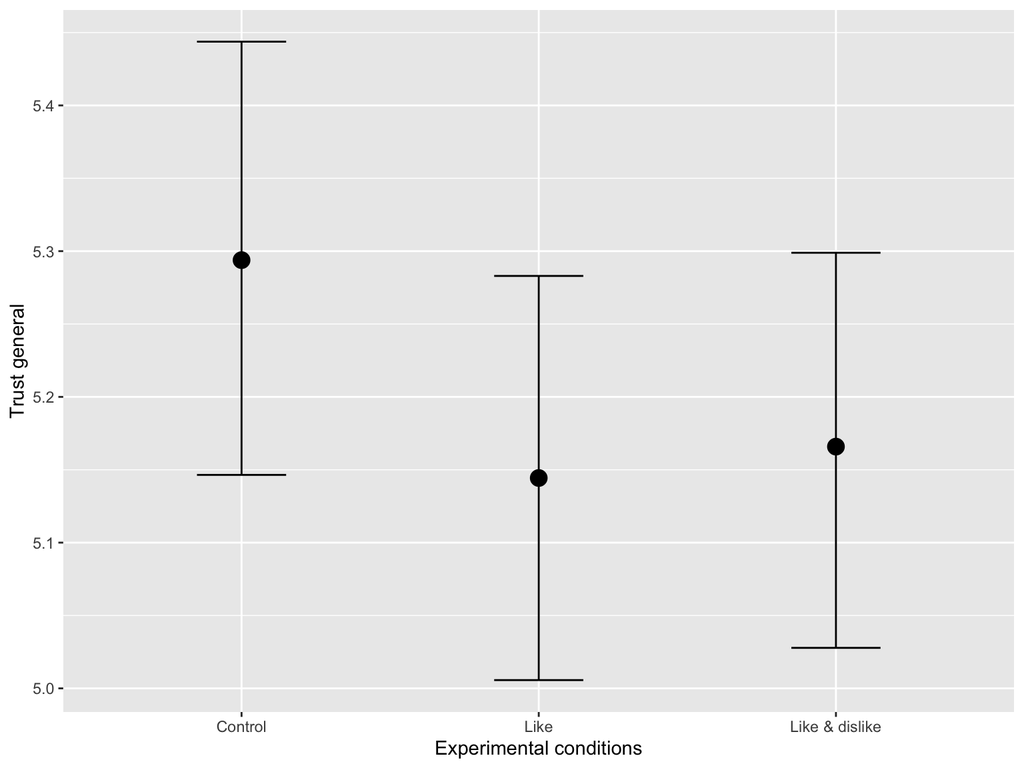

```r
run_hurdles(
  object = d,
  name = "trust_ctrl",
  outcome = "trust_gen_fs",
  predictor = "version",
  y_lab = "Trust general",
  x_lab = "Experimental conditions"
  )
```

I then compare the likes and control conditions to the likes plus dislikes condition.

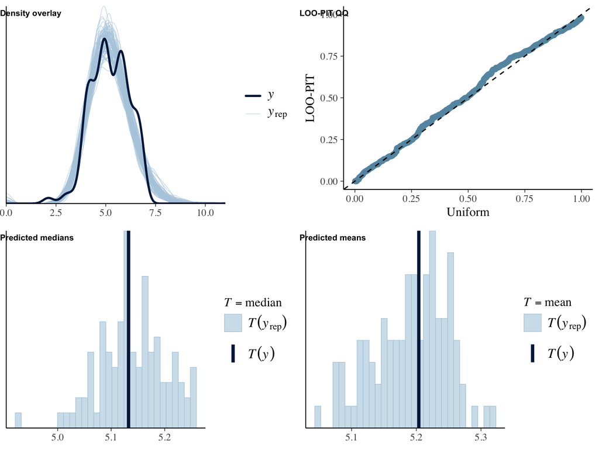

```
 Family: hurdle_gamma
  Links: mu = log; hu = logit
Formula: trust_gen_fs ~ 1 + age + male + edu + version_lkdslk
         hu ~ 1 + age + male + edu + version_lkdslk
   Data: object (Number of observations: 558)
  Draws: 4 chains, each with iter = 1000; warmup = 500; thin = 1;
         total post-warmup draws = 2000

Regression Coefficients:
                         Estimate Est.Error l-95% CI u-95% CI Rhat Bulk_ESS Tail_ESS
Intercept                    1.67      0.03     1.60     1.73 1.00     2158     1820
hu_Intercept               -10.16      5.98   -23.43    -0.16 1.00     1007     1117
age                         -0.00      0.00    -0.00     0.00 1.00     2079     1326
male                         0.00      0.02    -0.03     0.03 1.00     2126     1469
edu                          0.00      0.01    -0.02     0.02 1.00     2531     1369
version_lkdslkLike          -0.00      0.02    -0.04     0.03 1.00     1772     1650
version_lkdslkControl        0.03      0.02    -0.01     0.07 1.00     1865     1616
hu_age                       0.00      0.08    -0.15     0.16 1.01     1187     1097
hu_male                     -0.08      3.15    -6.71     6.27 1.01     1043      977
hu_edu                      -0.20      1.67    -3.79     2.75 1.00     1577     1083
hu_version_lkdslkLike        0.47      4.38    -7.83     9.76 1.00      842      866
hu_version_lkdslkControl     0.49      4.49    -8.29     9.99 1.00      878      784

Further Distributional Parameters:
      Estimate Est.Error l-95% CI u-95% CI Rhat Bulk_ESS Tail_ESS
shape    27.43      1.68    24.24    30.74 1.00     2347     1357

Draws were sampled using sampling(NUTS). For each parameter, Bulk_ESS
and Tail_ESS are effective sample size measures, and Rhat is the potential
scale reduction factor on split chains (at convergence, Rhat = 1).
```

```
Results of marginal effects:
       Outcome           term                 contrast estimate conf.low conf.high
1 trust_gen_fs            age                    dY/dX -0.00312 -0.00886   0.00259
2 trust_gen_fs            edu                    dY/dX  0.00117 -0.10267   0.10714
3 trust_gen_fs           male                    1 - 0  0.01574 -0.15447   0.18178
4 trust_gen_fs version_lkdslk Control - Like & dislike  0.13553 -0.07930   0.34367
5 trust_gen_fs version_lkdslk    Like - Like & dislike -0.01656 -0.22124   0.18351
```

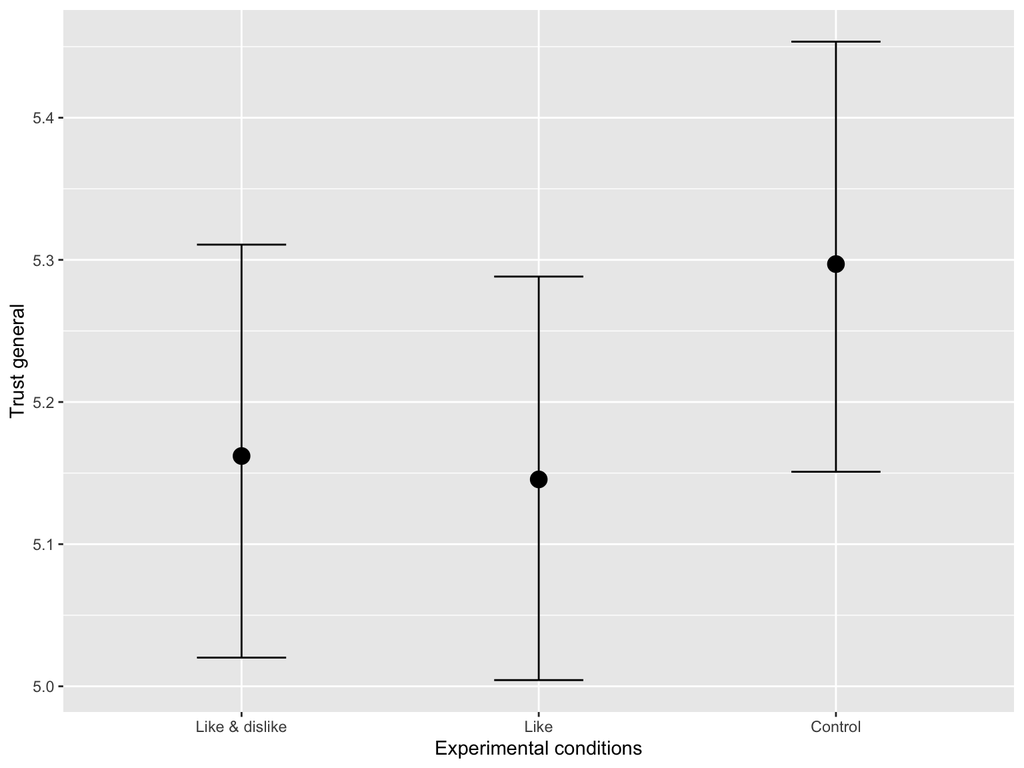

```r
run_hurdles(
  object = d,
  name = "trust_lkdslk",
  outcome = "trust_gen_fs",
  predictor = "version_lkdslk",
  y_lab = "Trust general",
  x_lab = "Experimental conditions"
  )
```